# Country Analysis Template

2023-11-29

## Background

The overall goal of this project is to reduce morbidity and mortality of sick children attending primary care facilities while supporting the rational and efficient use of diagnostics and medicines by healthcare providers. This study is focused on generating evidence for pulse oximetry and clinical decision support algorithms (CDSAs) in primary care. To determine the performance of the multimodal PO devices under investigation in this study, a cross-sectional diagnostic accuracy study will compare the index multimodal PO devices to an accepted reference standard.

The primary objective of this study is to determine the performance of available multimodal PO devices compared to an accepted reference standard by primary care providers assessing chidlren 0-59 months seeking care at the primary care level. Reference standards for the different clinical measurements include: Masimo Rad97 patient monitor (SpO2, PR), video derived annotated respiratory rate (RR), and digital infrared thermometer (temp). Secondary objectives include determining if any variability in performance is detected by age category or skin pigmentation and assessing interrater reliability.

This report contains data from **Kenya**.

# Section 1: Participant Characteristics

Leila

## Table 1: Participant Characteristics Overall and by Facility

Note: Reference measure summaries presented in this table (for measurements obtained at more than one time point) are the population mean/SD of the summarized measures (i.e., mean of the mean of M1-3).

|  | Overall | KYA01 | KYA02 |
| --- | --- | --- | --- |
| N | 719 | 362 | 357 |
| **Demographic Characteristics** |  |  |  |
| Age Category (%) |  |  |  |
| 0-1 month | 150 ( 20.9) | 69 ( 19.1) | 81 ( 22.8) |
| 2-11 months | 226 ( 31.5) | 117 ( 32.3) | 109 ( 30.6) |
| 12-59 months | 342 ( 47.6) | 176 ( 48.6) | 166 ( 46.6) |
| Sex = Male/Female (%) | 364/354 (50.7/49.3) | 168/194 (46.4/53.6) | 196/160 (55.1/44.9) |
| Relationship of caregiver to child (%) |  |  |  |
| Mother and Father | 10 ( 1.4) | 3 ( 0.8) | 7 ( 2.0) |
| Mother and Grandmother | 3 ( 0.4) | 3 ( 0.8) | 0 ( 0.0) |
| Mother only | 674 ( 93.9) | 342 ( 94.5) | 332 ( 93.3) |
| Father only | 4 ( 0.6) | 2 ( 0.6) | 2 ( 0.6) |
| Grandmother only | 13 ( 1.8) | 4 ( 1.1) | 9 ( 2.5) |
| Sibling | 3 ( 0.4) | 2 ( 0.6) | 1 ( 0.3) |
| Other family member | 8 ( 1.1) | 4 ( 1.1) | 4 ( 1.1) |
| Community Member | 2 ( 0.3) | 1 ( 0.3) | 1 ( 0.3) |
| Other | 1 ( 0.1) | 1 ( 0.3) | 0 ( 0.0) |
| **Reason for visit to clinic** |  |  |  |
| Visited due to Illness (%) | 718 ( 99.9) | 362 (100.0) | 356 ( 99.7) |
| Visited for Immunization (%) | 29 ( 4.0) | 1 ( 0.3) | 28 ( 7.8) |
| Visited for Routine Monitoring (%) | 30 ( 4.2) | 0 ( 0.0) | 30 ( 8.4) |
| Visited due to Trauma=False (%) | 719 (100.0) | 362 (100.0) | 357 (100.0) |
| Admission to inpatient unit of the facility=False (%) | 719 (100.0) | 362 (100.0) | 357 (100.0) |
| **Symptoms Present** |  |  |  |
| Cough (%) | 655 ( 91.1) | 354 ( 97.8) | 301 ( 84.3) |
| Difficulty/Rapid breathing (%) | 280 ( 38.9) | 64 ( 17.7) | 216 ( 60.5) |
| Fever (%) | 449 ( 62.4) | 284 ( 78.5) | 165 ( 46.2) |
| Diarrhea (%) | 67 ( 9.3) | 31 ( 8.6) | 36 ( 10.1) |
| Vomiting (%) | 56 ( 7.8) | 10 ( 2.8) | 46 ( 12.9) |
| Other (%) | 482 ( 67.0) | 202 ( 55.8) | 280 ( 78.4) |
| **Diagnosis** |  |  |  |
| Received Diagnosis (%) | 718 (100.0) | 362 (100.0) | 356 (100.0) |
| Dehydration | 15 ( 2.1) | 12 ( 3.3) | 3 ( 0.8) |
| Respiratory | 714 ( 99.3) | 362 (100.0) | 352 ( 98.6) |
| Digestive | 78 ( 10.8) | 42 ( 11.6) | 36 ( 10.1) |
| Malaria | 1 ( 0.1) | 1 ( 0.3) | 0 ( 0.0) |
| Fever | 287 ( 39.9) | 284 ( 78.5) | 3 ( 0.8) |
| Measles=False | 719 (100.0) | 362 (100.0) | 357 (100.0) |
| Ear infection | 4 ( 0.6) | 2 ( 0.6) | 2 ( 0.6) |
| Throat infection | 13 ( 1.8) | 0 ( 0.0) | 13 ( 3.6) |
| Other | 76 ( 10.6) | 38 ( 10.5) | 38 ( 10.6) |
| **Treatment received** |  |  |  |
| Received Treatment (%) | 713 ( 99.3) | 362 (100.0) | 351 ( 98.6) |
| Antibiotic | 533 ( 74.1) | 348 ( 96.1) | 185 ( 51.8) |
| Antimalarial | 1 ( 0.1) | 1 ( 0.3) | 0 ( 0.0) |
| Dehydration | 47 ( 6.5) | 21 ( 5.8) | 26 ( 7.3) |
| Bronchodilator | 48 ( 6.7) | 20 ( 5.5) | 28 ( 7.8) |
| Other | 696 ( 96.8) | 349 ( 96.4) | 347 ( 97.2) |
| **Physical Characteristics** |  |  |  |
| Height (cm) (mean (SD)) | 87.32 (87.37) | 96.35 (119.88) | 77.83 (20.09) |
| Weight (kg) (mean (SD)) | 18.73 (91.53) | 27.12 (127.33) | 9.92 (4.86) |
| MUAC (cm) (mean (SD)) | 14.02 (1.84) | 13.99 (1.78) | 14.05 (1.90) |
| Head Circumference (cm) (mean (SD)) | 45.55 (5.15) | 45.74 (5.07) | 45.35 (5.23) |
| **Reference Measurements** |  |  |  |
| Hemocue (g/dL) (mean (SD)) | 10.88 (1.75) | 10.76 (1.55) | 11.01 (1.93) |
| SpO2 (reference) (mean (SD)) | 95.30 (2.53) | 95.39 (2.74) | 95.20 (2.28) |
| Pulse Rate (reference) (mean (SD)) | 132.86 (20.76) | 132.40 (20.16) | 133.34 (21.38) |
| Temperature (reference) (mean (SD)) | 38.28 (24.45) | 39.26 (33.72) | 37.20 (0.52) |
| Profusion Index (reference) (mean (SD)) | 2.75 (1.53) | 2.74 (1.42) | 2.76 (1.63) |

## List of free responses entered for ‘other’ fields

### Symptoms

```
## # A tibble: 482 × 2
##     ppt_id    visit_reason_ill_sxs_oth
##     <chr>     <chr>
##   1 13407-1   "Flu-like symptoms "
##   2 13407-4   "Blocked nose, abdominal pain"
##   3 13407-7   "Nasal congestion, runny nose"
##   4 13407-8   "Pain while urinating"
##   5 13407-9   "Nasal congestion"
##   6 13407-12  "Nasal congestion "
##   7 13407-13  "Enlarged tonsils"
##   8 13407-14  "Watery eyes and eye pain"
##   9 13407-15  "Runny nose"
##  10 13407-16  "Runny nose"
##  11 13407-19  "Running nose "
##  12 13407-20  "Running nose "
```

[output cut: 470 more lines]

### Diagnosis

```
## # A tibble: 76 × 2
##    ppt_id    reported_dx_oth
##    <chr>     <chr>
##  1 13407-8   "Urinary tract infection"
##  2 13407-70  "Atopic dermatitis"
##  3 13407-87  "Dermatological "
##  4 13407-98  "Dermatological "
##  5 13407-107 "Dermatological "
##  6 13407-108 "Dermatological"
##  7 13407-116 "Dermatological "
##  8 13407-117 "Eye infection "
##  9 13407-134 "Dermatological "
## 10 13407-135 "Dermatological "
## 11 13407-141 "Dermatological "
## 12 13407-152 "Dermatological "
```

[output cut: 64 more lines]

### Treatment

```
## # A tibble: 696 × 2
##     ppt_id    reported_tx_oth
##     <chr>     <chr>
##   1 13407-1   "Antipyretic, antihistamine"
##   2 13407-2   "Antihistamines, antipyretic "
##   3 13407-3   "Saline nasal drops, antipyretic, antihistamine "
##   4 13407-4   "Inhaled corticosteroid "
##   5 13407-5   "Antipyretic "
##   6 13407-6   "Oral corticosteroid "
##   7 13407-7   "Antihistamines, antipyretic "
##   8 13407-8   "Antihistamines, nasal drops"
##   9 13407-9   "antihistamine, steroid/ antibiotic ear drops"
##  10 13407-10  "Antipyretic, nasal drops"
##  11 13407-11  "Antipyretic, antihistamine "
##  12 13407-13  "Cough syrup, antihistamine "
```

[output cut: 684 more lines]

# Section 2: Measurement Characteristics & Precision

Leila

## Reference

### 0-1 month

| Measurement Characteristics and Precision across Measurement Attempts, Mean (SD) [Min, Max] %CV Participant ID | Measurement Characteristics and Precision across Measurement Attempts, Mean (SD) [Min, Max] %CV Temperature | Measurement Characteristics and Precision across Measurement Attempts, Mean (SD) [Min, Max] %CV Oxygen | Measurement Characteristics and Precision across Measurement Attempts, Mean (SD) [Min, Max] %CV Pulse Rate | Measurement Characteristics and Precision across Measurement Attempts, Mean (SD) [Min, Max] %CV Profusion Index |
| --- | --- | --- | --- | --- |
| 13407-99 | NaN (NA) [Inf,-Inf] NA% | 95.7 (0.6) [95,96] 0% | 180.7 (9.5) [170,188] 10% | 1.4 (0.2) [1.3,1.6] 10% |
| 13407-100 | NaN (NA) [Inf,-Inf] NA% | 96 (1) [95,97] 0% | 176.7 (6.7) [171,184] 0% | 1.2 (0.3) [0.99,1.5] 20% |
| 13407-101 | NaN (NA) [Inf,-Inf] NA% | NaN (NA) [Inf,-Inf] NA% | NaN (NA) [Inf,-Inf] NA% | NaN (NA) [Inf,-Inf] NA% |
| 13407-102 | NaN (NA) [Inf,-Inf] NA% | 93.7 (1.5) [92,95] 0% | 148.3 (5.5) [143,154] 0% | 1.1 (0.1) [1,1.1] 10% |
| 13407-103 | NaN (NA) [Inf,-Inf] NA% | 97 (2) [95,99] 0% | 163.7 (6.8) [156,169] 0% | 1.1 (0.2) [0.82,1.2] 20% |
| 13407-159 | 37.1 (0) [37.1,37.1] 0% | 95 (0) [95,95] 0% | 133 (7) [125,138] 10% | 2.4 (0.2) [2.2,2.6] 10% |
| 13407-161 | 36.8 (0.1) [36.8,36.9] 0% | 94.7 (2.1) [93,97] 0% | 152.7 (0.6) [152,153] 0% | 2 (0.2) [1.9,2.2] 10% |
| 13407-189 | 36.8 (0.2) [36.6,37] 0% | 88 (6.1) [81,92] 10% | 147.3 (5.7) [141,152] 0% | 1.8 (0.3) [1.6,2.2] 20% |
| 13407-216 | 36.7 (NA) [36.7,36.7] NA% | 96 (NA) [96,96] NA% | 136 (NA) [136,136] NA% | 0.7 (NA) [0.65,0.65] NA% |
| 13407-228 | 36.7 (0.2) [36.5,36.8] 0% | 92 (1) [91,93] 0% | 156.3 (3.2) [154,160] 0% | 1.4 (0.1) [1.3,1.5] 10% |
| 13407-252 | 37.1 (0.2) [36.9,37.3] 0% | 98 (1.7) [97,100] 0% | 142.3 (2.1) [140,144] 0% | 0.6 (0.1) [0.59,0.73] 20% |
| 13407-257 | 36.8 (0.1) [36.7,36.9] 0% | 94 (1) [93,95] 0% | 138.7 (1.5) [137,140] 0% | 2.3 (0.4) [1.8,2.6] 20% |
| 13407-266 | NaN (NA) [Inf,-Inf] NA% | 94 (0) [94,94] 0% | 172.7 (0.6) [172,173] 0% | 2.1 (0.1) [2,2.2] 0% |
| 13407-272 | NaN (NA) [Inf,-Inf] NA% | 96.3 (0.6) [96,97] 0% | 168.3 (4.5) [164,173] 0% | 2.6 (0.3) [2.4,2.9] 10% |
| 13407-274 | NaN (NA) [Inf,-Inf] NA% | 91.7 (2.5) [89,94] 0% | 157 (3.6) [153,160] 0% | 0.4 (0) [0.37,0.4] 0% |
| 13407-275 | NaN (NA) [Inf,-Inf] NA% | 94 (1) [93,95] 0% | 158.3 (3.8) [154,161] 0% | 1.4 (0.2) [1.1,1.5] 10% |
| 13407-276 | NaN (NA) [Inf,-Inf] NA% | 89.3 (1.2) [88,90] 0% | 166.7 (4.2) [162,170] 0% | 2 (0.2) [1.8,2.2] 10% |
| 13407-277 | NaN (NA) [Inf,-Inf] NA% | 95 (2) [93,97] 0% | 139.7 (9.9) [133,151] 10% | 1.9 (0.4) [1.5,2.3] 20% |
| 13407-278 | NaN (NA) [Inf,-Inf] NA% | 96.3 (0.6) [96,97] 0% | 148.3 (4.5) [144,153] 0% | 1.8 (0.2) [1.7,2] 10% |
| 13407-279 | NaN (NA) [Inf,-Inf] NA% | 93.3 (0.6) [93,94] 0% | 146.3 (4) [142,150] 0% | 2.1 (0.5) [1.5,2.5] 20% |
| 13407-280 | NaN (NA) [Inf,-Inf] NA% | 97 (0) [97,97] 0% | 139 (8.2) [130,146] 10% | 4.8 (0.6) [4.1,5.3] 10% |
| 13407-281 | NaN (NA) [Inf,-Inf] NA% | 100 (0) [100,100] 0% | 162.3 (7.6) [154,169] 0% | 0.7 (0.5) [0.39,1.3] 70% |
| 13407-282 | NaN (NA) [Inf,-Inf] NA% | 96.7 (1.2) [96,98] 0% | 161 (2) [159,163] 0% | 0.6 (0) [0.51,0.6] 0% |
| 13407-283 | NaN (NA) [Inf,-Inf] NA% | 98.7 (0.6) [98,99] 0% | 152.3 (1.5) [151,154] 0% | 0.4 (0) [0.35,0.43] 0% |
| 13407-284 | NaN (NA) [Inf,-Inf] NA% | 91.7 (0.6) [91,92] 0% | 131.3 (1.5) [130,133] 0% | 1.4 (0.1) [1.3,1.5] 10% |
| 13407-285 | NaN (NA) [Inf,-Inf] NA% | 94.7 (0.6) [94,95] 0% | 165.3 (5.9) [161,172] 0% | 1.5 (0.4) [1.2,1.9] 30% |
| 13407-286 | NaN (NA) [Inf,-Inf] NA% | 98.3 (1.2) [97,99] 0% | 132 (8.5) [123,140] 10% | 1.6 (0.1) [1.5,1.7] 10% |
| 13407-287 | NaN (NA) [Inf,-Inf] NA% | 99 (0) [99,99] 0% | 164.3 (4.7) [159,168] 0% | 0.7 (0.1) [0.59,0.73] 10% |
| 13407-288 | NaN (NA) [Inf,-Inf] NA% | 94.7 (1.2) [94,96] 0% | 165.3 (1.2) [164,166] 0% | 1.4 (0.4) [1,1.7] 30% |
| 13407-289 | NaN (NA) [Inf,-Inf] NA% | 93 (1) [92,94] 0% | 156 (4.6) [151,160] 0% | 1.1 (0.3) [0.81,1.4] 30% |

[output cut: 120 more lines]

### 2-11 months

| Measurement Characteristics and Precision across Measurement Attempts, Mean (SD) [Min, Max] %CV Participant ID | Measurement Characteristics and Precision across Measurement Attempts, Mean (SD) [Min, Max] %CV Temperature | Measurement Characteristics and Precision across Measurement Attempts, Mean (SD) [Min, Max] %CV Oxygen | Measurement Characteristics and Precision across Measurement Attempts, Mean (SD) [Min, Max] %CV Pulse Rate | Measurement Characteristics and Precision across Measurement Attempts, Mean (SD) [Min, Max] %CV Profusion Index |
| --- | --- | --- | --- | --- |
| 13407-18 | 36.7 (0) [36.7,36.7] 0% | 89.7 (1.5) [88,91] 0% | 125.3 (0.6) [125,126] 0% | 2.8 (0.2) [2.6,3] 10% |
| 13407-70 | NaN (NA) [Inf,-Inf] NA% | NaN (NA) [Inf,-Inf] NA% | NaN (NA) [Inf,-Inf] NA% | NaN (NA) [Inf,-Inf] NA% |
| 13407-73 | NaN (NA) [Inf,-Inf] NA% | 96.7 (0.6) [96,97] 0% | 135.3 (5.5) [129,139] 0% | 2.7 (1.4) [1.8,4.3] 50% |
| 13407-76 | NaN (NA) [Inf,-Inf] NA% | 95 (1.7) [93,96] 0% | 148.3 (17.5) [129,163] 10% | 1.2 (0.2) [1,1.4] 20% |
| 13407-79 | NaN (NA) [Inf,-Inf] NA% | 95.3 (0.6) [95,96] 0% | 129 (3.5) [127,133] 0% | 7 (0) [7,7] 0% |
| 13407-83 | NaN (NA) [Inf,-Inf] NA% | 96 (NA) [96,96] NA% | 150 (NA) [150,150] NA% | 1.5 (NA) [1.5,1.5] NA% |
| 13407-84 | NaN (NA) [Inf,-Inf] NA% | 97.3 (0.6) [97,98] 0% | 148.7 (5) [144,154] 0% | 2.3 (0.8) [1.4,2.8] 30% |
| 13407-87 | NaN (NA) [Inf,-Inf] NA% | 96.7 (0.6) [96,97] 0% | 134.7 (7.2) [130,143] 10% | 3.1 (1) [2.1,4.1] 30% |
| 13407-96 | NaN (NA) [Inf,-Inf] NA% | 94.3 (1.2) [93,95] 0% | 160.3 (4.2) [157,165] 0% | 5 (0.1) [4.9,5.1] 0% |
| 13407-104 | NaN (NA) [Inf,-Inf] NA% | 94.3 (2.1) [92,96] 0% | 144.3 (3.2) [142,148] 0% | 1.7 (0.1) [1.6,1.8] 10% |
| 13407-105 | NaN (NA) [Inf,-Inf] NA% | 96.3 (1.2) [95,97] 0% | 146.7 (2.1) [145,149] 0% | 1.6 (0.5) [1.2,2.1] 30% |
| 13407-106 | NaN (NA) [Inf,-Inf] NA% | 90.7 (0.6) [90,91] 0% | 132.7 (2.1) [131,135] 0% | 3.3 (0.1) [3.3,3.4] 0% |
| 13407-107 | NaN (NA) [Inf,-Inf] NA% | 96.3 (2.9) [93,98] 0% | 175 (5.3) [171,181] 0% | 1.2 (0.1) [1.2,1.3] 10% |
| 13407-108 | NaN (NA) [Inf,-Inf] NA% | 97 (0) [97,97] 0% | 120 (1.7) [119,122] 0% | 3.6 (0.3) [3.3,3.9] 10% |
| 13407-109 | NaN (NA) [Inf,-Inf] NA% | 91.7 (0.6) [91,92] 0% | 159.3 (2.3) [158,162] 0% | 1.3 (0.1) [1.2,1.4] 10% |
| 13407-110 | NaN (NA) [Inf,-Inf] NA% | 95 (1) [94,96] 0% | 135.7 (1.5) [134,137] 0% | 1.5 (0.1) [1.4,1.5] 10% |
| 13407-111 | NaN (NA) [Inf,-Inf] NA% | 91.3 (0.6) [91,92] 0% | 136.7 (3.2) [133,139] 0% | 1 (0.1) [1,1.1] 10% |
| 13407-112 | NaN (NA) [Inf,-Inf] NA% | 95.3 (0.6) [95,96] 0% | 160 (2.6) [158,163] 0% | 1.2 (0.1) [1.1,1.2] 10% |
| 13407-113 | NaN (NA) [Inf,-Inf] NA% | 95.3 (0.6) [95,96] 0% | 129 (3) [126,132] 0% | 1.9 (0.3) [1.7,2.3] 20% |
| 13407-114 | NaN (NA) [Inf,-Inf] NA% | 93.7 (0.6) [93,94] 0% | 132.7 (3.8) [130,137] 0% | 2 (0.3) [1.7,2.2] 10% |
| 13407-115 | NaN (NA) [Inf,-Inf] NA% | 91.3 (0.6) [91,92] 0% | 148.3 (2.9) [145,150] 0% | 3.2 (0) [3.2,3.2] 0% |
| 13407-116 | NaN (NA) [Inf,-Inf] NA% | NaN (NA) [Inf,-Inf] NA% | NaN (NA) [Inf,-Inf] NA% | NaN (NA) [Inf,-Inf] NA% |
| 13407-117 | NaN (NA) [Inf,-Inf] NA% | 94.3 (0.6) [94,95] 0% | 130.3 (0.6) [130,131] 0% | 1.8 (0.1) [1.7,1.9] 10% |
| 13407-118 | NaN (NA) [Inf,-Inf] NA% | 97 (1) [96,98] 0% | 167 (3.6) [163,170] 0% | 2.9 (0) [2.9,2.9] 0% |
| 13407-119 | NaN (NA) [Inf,-Inf] NA% | 97.7 (0.6) [97,98] 0% | 151 (5.6) [145,156] 0% | 2.3 (0.3) [2,2.6] 10% |
| 13407-120 | NaN (NA) [Inf,-Inf] NA% | 92.7 (0.6) [92,93] 0% | 145.7 (3.1) [143,149] 0% | 2.5 (0.4) [2.1,2.8] 20% |
| 13407-121 | NaN (NA) [Inf,-Inf] NA% | 95.7 (0.6) [95,96] 0% | 143 (3) [140,146] 0% | 3.6 (0.2) [3.4,3.8] 10% |
| 13407-122 | NaN (NA) [Inf,-Inf] NA% | 96 (0) [96,96] 0% | 125.7 (2.3) [123,127] 0% | 1.6 (0.3) [1.2,1.8] 20% |
| 13407-123 | NaN (NA) [Inf,-Inf] NA% | 95.3 (0.6) [95,96] 0% | 117.3 (3.5) [114,121] 0% | 3.1 (0.1) [3,3.2] 0% |
| 13407-131 | 36.7 (0.1) [36.6,36.8] 0% | 97 (0) [97,97] 0% | 103.7 (9.1) [94,112] 10% | 3.4 (0.8) [2.6,4.1] 20% |

[output cut: 196 more lines]

### 12-59 months

| Measurement Characteristics and Precision across Measurement Attempts, Mean (SD) [Min, Max] %CV Participant ID | Measurement Characteristics and Precision across Measurement Attempts, Mean (SD) [Min, Max] %CV Temperature | Measurement Characteristics and Precision across Measurement Attempts, Mean (SD) [Min, Max] %CV Oxygen | Measurement Characteristics and Precision across Measurement Attempts, Mean (SD) [Min, Max] %CV Pulse Rate | Measurement Characteristics and Precision across Measurement Attempts, Mean (SD) [Min, Max] %CV Profusion Index |
| --- | --- | --- | --- | --- |
| 13407-1 | 37.5 (0.1) [37.4,37.6] 0% | 95 (0) [95,95] 0% | 122.3 (2.3) [121,125] 0% | 5.7 (0.6) [5.1,6.3] 10% |
| 13407-2 | 35.4 (0) [35.4,35.4] 0% | 95.3 (0.6) [95,96] 0% | 131 (3) [128,134] 0% | 3.6 (0.9) [2.5,4.3] 20% |
| 13407-3 | 36.9 (0.2) [36.8,37.1] 0% | 95.7 (0.6) [95,96] 0% | 98.7 (0.6) [98,99] 0% | 7.1 (0.4) [6.6,7.4] 10% |
| 13407-4 | 37.1 (0.1) [37,37.2] 0% | 96.3 (1.2) [95,97] 0% | 111.3 (5.1) [107,117] 0% | 0.7 (0.2) [0.55,0.94] 30% |
| 13407-5 | 37 (0.3) [36.6,37.2] 0% | 95.7 (0.6) [95,96] 0% | 110.7 (2.1) [109,113] 0% | 3.4 (0.9) [2.7,4.4] 30% |
| 13407-6 | 38.4 (0.1) [38.4,38.5] 0% | 88.7 (0.6) [88,89] 0% | 155.7 (1.2) [155,157] 0% | 2.8 (0.1) [2.7,2.9] 0% |
| 13407-7 | 37.4 (0.3) [37,37.6] 0% | 93.3 (1.5) [92,95] 0% | 123.3 (2.5) [121,126] 0% | 2.5 (0.3) [2.3,2.8] 10% |
| 13407-8 | 36.7 (0.1) [36.6,36.8] 0% | 97 (0) [97,97] 0% | 117 (3) [114,120] 0% | 8.1 (0.2) [7.9,8.2] 0% |
| 13407-9 | 36.8 (0.3) [36.5,37.1] 0% | 97 (0) [97,97] 0% | 115.7 (4.6) [113,121] 0% | 4 (1.4) [2.4,4.9] 30% |
| 13407-10 | 38.2 (0.3) [37.8,38.4] 0% | 93.3 (0.6) [93,94] 0% | 157.7 (9.1) [151,168] 10% | 2.7 (0.5) [2.1,3.1] 20% |
| 13407-11 | 38.2 (0.2) [38,38.3] 0% | 95.3 (0.6) [95,96] 0% | 125.7 (1.2) [125,127] 0% | 2.3 (0.8) [1.4,2.9] 30% |
| 13407-12 | 38.1 (0.3) [37.9,38.4] 0% | 93.7 (1.5) [92,95] 0% | 157.3 (0.6) [157,158] 0% | 1.9 (0.3) [1.6,2.2] 20% |
| 13407-13 | 36.7 (0.2) [36.5,36.8] 0% | 98 (0) [98,98] 0% | 111 (6.2) [104,116] 10% | 4.8 (0.1) [4.7,4.8] 0% |
| 13407-14 | 37.1 (0.2) [37,37.3] 0% | 96.7 (0.6) [96,97] 0% | 122.3 (3.8) [118,125] 0% | 4.4 (0.5) [4.1,5] 10% |
| 13407-15 | 37.6 (0.2) [37.4,37.7] 0% | 92.3 (2.1) [90,94] 0% | 148 (5.6) [143,154] 0% | 1.9 (0.6) [1.5,2.5] 30% |
| 13407-16 | 37.5 (0.2) [37.3,37.6] 0% | 95.7 (0.6) [95,96] 0% | 111 (2) [109,113] 0% | 4.9 (1.5) [3.2,5.9] 30% |
| 13407-17 | 37 (0.1) [36.9,37] 0% | 96 (0) [96,96] 0% | 105.3 (3.8) [101,108] 0% | 5.4 (0.1) [5.4,5.5] 0% |
| 13407-19 | 36.9 (0.2) [36.8,37.1] 0% | 96 (0) [96,96] 0% | 123.3 (6.7) [119,131] 10% | 2.7 (0.2) [2.5,2.9] 10% |
| 13407-20 | 37.1 (0.3) [36.8,37.4] 0% | 97.7 (0.6) [97,98] 0% | 123 (4.4) [118,126] 0% | 0.8 (0.1) [0.72,0.83] 10% |
| 13407-21 | 37.3 (0.2) [37.2,37.5] 0% | 97 (0) [97,97] 0% | 106.3 (4.5) [102,111] 0% | 5.5 (0.2) [5.3,5.7] 0% |
| 13407-22 | 37 (0.1) [37,37.1] 0% | 96.7 (0.6) [96,97] 0% | 86 (1) [85,87] 0% | 7.7 (0.5) [7.2,8.1] 10% |
| 13407-38 | 37.4 (0.2) [37.3,37.7] 0% | 96.7 (0.6) [96,97] 0% | 112 (3.5) [110,116] 0% | 1.8 (0.2) [1.6,2] 10% |
| 13407-39 | 37.2 (0.2) [37,37.4] 0% | 94.7 (0.6) [94,95] 0% | 100.7 (1.2) [100,102] 0% | 5.6 (0.4) [5.2,5.9] 10% |
| 13407-40 | NaN (NA) [Inf,-Inf] NA% | 96 (1) [95,97] 0% | 116.7 (2.1) [115,119] 0% | 5.1 (0.1) [5,5.2] 0% |
| 13407-41 | NaN (NA) [Inf,-Inf] NA% | 96 (0) [96,96] 0% | 122 (4.4) [117,125] 0% | 4.7 (1.3) [3.6,6.1] 30% |
| 13407-42 | NaN (NA) [Inf,-Inf] NA% | 94.7 (0.6) [94,95] 0% | 113 (3.6) [110,117] 0% | 1.9 (0.1) [1.9,2] 10% |
| 13407-43 | NaN (NA) [Inf,-Inf] NA% | 97 (0) [97,97] 0% | 110.7 (0.6) [110,111] 0% | 5.3 (0.2) [5.2,5.6] 0% |
| 13407-44 | NaN (NA) [Inf,-Inf] NA% | 95.7 (0.6) [95,96] 0% | 110.3 (2.3) [109,113] 0% | 2.1 (0.1) [2,2.1] 0% |
| 13407-45 | NaN (NA) [Inf,-Inf] NA% | 93 (0) [93,93] 0% | 133.7 (0.6) [133,134] 0% | 3.1 (0.2) [3,3.3] 10% |
| 13407-46 | NaN (NA) [Inf,-Inf] NA% | 94.7 (0.6) [94,95] 0% | 110.7 (1.5) [109,112] 0% | 3.6 (0.2) [3.4,3.7] 10% |

[output cut: 312 more lines]

## Rad-G Temp (Masimo)

### 0-1 month

| Measurement Characteristics and Precision across Measurement Attempts, Mean (SD) [Min, Max] %CV Participant ID | Measurement Characteristics and Precision across Measurement Attempts, Mean (SD) [Min, Max] %CV Temperature | Measurement Characteristics and Precision across Measurement Attempts, Mean (SD) [Min, Max] %CV Oxygen | Measurement Characteristics and Precision across Measurement Attempts, Mean (SD) [Min, Max] %CV Pulse Rate | Measurement Characteristics and Precision across Measurement Attempts, Mean (SD) [Min, Max] %CV Profusion Index |
| --- | --- | --- | --- | --- |
| 13407-189 | 36.8 (0.2) [36.6,37] 0% | 88 (6.1) [81,92] 10% | 147.3 (5.7) [141,152] 0% | 1.8 (0.3) [1.6,2.2] 20% |
| 13407-216 | 36.7 (NA) [36.7,36.7] NA% | 96 (NA) [96,96] NA% | 136 (NA) [136,136] NA% | 0.7 (NA) [0.65,0.65] NA% |
| 13407-228 | 36.7 (0.2) [36.5,36.8] 0% | 92 (1) [91,93] 0% | 156.3 (3.2) [154,160] 0% | 1.4 (0.1) [1.3,1.5] 10% |
| 13407-252 | 37.1 (0.2) [36.9,37.3] 0% | 98 (1.7) [97,100] 0% | 142.3 (2.1) [140,144] 0% | 0.6 (0.1) [0.59,0.73] 20% |
| 13407-257 | 36.8 (0.1) [36.7,36.9] 0% | 94 (1) [93,95] 0% | 138.7 (1.5) [137,140] 0% | 2.3 (0.4) [1.8,2.6] 20% |
| 13407-333 | 37.4 (0.1) [37.3,37.5] 0% | 99 (0) [99,99] 0% | 129.7 (1.5) [128,131] 0% | 0.8 (0) [0.81,0.89] 0% |
| 13407-334 | 37.1 (0.1) [37,37.2] 0% | 93.7 (1.2) [93,95] 0% | 145.3 (2.9) [142,147] 0% | 1.2 (0.2) [0.95,1.4] 20% |
| 13407-335 | 37.2 (0.1) [37.1,37.3] 0% | 98 (1) [97,99] 0% | 155.7 (1.5) [154,157] 0% | 0.8 (0.3) [0.45,1] 40% |
| 13407-336 | 37 (0.2) [36.8,37.1] 0% | 94.3 (0.6) [94,95] 0% | 127.7 (1.2) [127,129] 0% | 2.1 (0.1) [2,2.1] 0% |
| 13407-337 | 36.9 (0.4) [36.5,37.3] 0% | 92.7 (4.2) [88,96] 0% | 166.3 (3.1) [163,169] 0% | 1.4 (0.2) [1.2,1.6] 10% |
| 13407-338 | 37 (0.1) [36.9,37.1] 0% | 94.3 (0.6) [94,95] 0% | 171.3 (10.1) [162,182] 10% | 2.5 (0.3) [2.3,2.8] 10% |
| 13407-339 | 37.2 (0.1) [37.1,37.3] 0% | 95.3 (0.6) [95,96] 0% | 155 (5.2) [149,158] 0% | 1 (0.2) [0.82,1.1] 20% |
| 13407-340 | 37.1 (0.1) [37.1,37.2] 0% | 91.3 (1.2) [90,92] 0% | 135 (2.6) [133,138] 0% | 0.9 (0.4) [0.62,1.3] 40% |
| 13407-341 | 37.1 (0.1) [37.1,37.2] 0% | 89.7 (4.7) [86,95] 10% | 142.3 (3.1) [139,145] 0% | 5 (0.3) [4.7,5.2] 10% |
| 13407-342 | 37.3 (0.2) [37.1,37.5] 0% | 96.7 (0.6) [96,97] 0% | 134.7 (3.5) [131,138] 0% | 2.4 (0.1) [2.3,2.5] 0% |
| 13407-343 | 37.1 (0.1) [37,37.1] 0% | 95.3 (0.6) [95,96] 0% | 153 (3) [150,156] 0% | 2.6 (0.4) [2.2,2.9] 20% |
| 13407-344 | 36.6 (0) [36.6,36.6] 0% | 94.7 (0.6) [94,95] 0% | 128.7 (3.5) [125,132] 0% | 2.3 (0) [2.3,2.3] 0% |
| 13407-345 | 37.2 (0) [37.2,37.2] 0% | 97.7 (0.6) [97,98] 0% | 149.3 (0.6) [149,150] 0% | 1.4 (0.1) [1.3,1.5] 10% |
| 13407-346 | 36.9 (0.2) [36.8,37.1] 0% | 97.3 (0.6) [97,98] 0% | 138.7 (4) [135,143] 0% | 1.7 (0.1) [1.6,1.8] 10% |
| 13407-347 | 37.1 (0) [37.1,37.1] 0% | 98 (0) [98,98] 0% | 152 (1.7) [150,153] 0% | 1.2 (0.1) [1.2,1.3] 10% |
| 13407-348 | 37.3 (0.2) [37.2,37.5] 0% | 98 (1) [97,99] 0% | 148 (3.6) [145,152] 0% | 0.8 (0.1) [0.7,0.94] 10% |
| 13407-349 | 37.3 (0.2) [37.1,37.4] 0% | 94 (0) [94,94] 0% | 141.3 (0.6) [141,142] 0% | 1.7 (0.2) [1.4,1.8] 10% |
| 13407-350 | 37.3 (0.3) [37,37.5] 0% | 95 (1) [94,96] 0% | 159 (2) [157,161] 0% | 1.9 (0.4) [1.6,2.3] 20% |
| 13407-351 | 37.3 (0.1) [37.2,37.4] 0% | 96.7 (0.6) [96,97] 0% | 152 (1.7) [150,153] 0% | 0.8 (0.4) [0.46,1.2] 50% |
| 13407-352 | 37.9 (0.3) [37.6,38.1] 0% | 98 (0) [98,98] 0% | 168.3 (0.6) [168,169] 0% | 0.5 (0) [0.47,0.5] 0% |
| 15681-258 | 37 (0.3) [36.7,37.2] 0% | 92 (2.6) [89,94] 0% | 131 (3) [128,134] 0% | 1.5 (0) [1.5,1.5] 0% |
| 15681-259 | 36.9 (0.2) [36.6,37] 0% | 89 (3) [86,92] 0% | 140.3 (3.8) [136,143] 0% | 1.4 (0.3) [1.1,1.7] 20% |
| 15681-260 | 36.8 (0.1) [36.8,36.9] 0% | 93.7 (0.6) [93,94] 0% | 146.3 (0.6) [146,147] 0% | 2.4 (0.3) [2.2,2.8] 10% |
| 15681-261 | 36.9 (0.2) [36.7,37.1] 0% | 94.3 (0.6) [94,95] 0% | 143.3 (8.5) [135,152] 10% | 2.3 (0.1) [2.2,2.3] 0% |
| 15681-262 | 37.4 (0.1) [37.4,37.5] 0% | 95.3 (1.5) [94,97] 0% | 151 (7) [146,159] 0% | 1 (0.2) [0.75,1.2] 20% |
| 15681-267 | 36.5 (0.2) [36.4,36.7] 0% | 97 (0) [97,97] 0% | 140.3 (5.8) [137,147] 0% | 2 (0.3) [1.7,2.3] 10% |
| 15681-269 | 36.6 (0.2) [36.4,36.8] 0% | 97.7 (3.2) [94,100] 0% | 152.3 (7) [145,159] 0% | 2.1 (0.4) [1.6,2.4] 20% |
| 15681-271 | 36.9 (0.2) [36.7,37.1] 0% | 88.7 (1.5) [87,90] 0% | 131.3 (13.1) [121,146] 10% | 1.2 (0.1) [1.1,1.3] 10% |
| 15681-274 | 36.7 (0) [36.7,36.7] 0% | 92.7 (0.6) [92,93] 0% | 137 (1) [136,138] 0% | 3.1 (0.6) [2.5,3.5] 20% |
| 15681-275 | 36.7 (0.2) [36.5,36.9] 0% | 95.3 (0.6) [95,96] 0% | 155.3 (4) [151,159] 0% | 4.8 (1.7) [3.5,6.7] 40% |
| 15681-277 | 36.8 (0.3) [36.6,37.1] 0% | 98 (1) [97,99] 0% | 150.3 (11.5) [137,157] 10% | 4.2 (2) [2.1,6] 50% |
| 15681-280 | 36.4 (0) [36.4,36.4] 0% | 95 (1) [94,96] 0% | 155.3 (4) [151,159] 0% | 5.7 (0.6) [5,6] 10% |
| 15681-283 | 37 (0.1) [37,37.1] 0% | 99 (1) [98,100] 0% | 157.7 (3.2) [154,160] 0% | 1.8 (0.1) [1.7,1.9] 10% |
| 15681-284 | 36.7 (0.1) [36.6,36.7] 0% | 98 (1) [97,99] 0% | 161.3 (1.5) [160,163] 0% | 2.7 (0.7) [1.9,3.2] 30% |
| 15681-286 | 37.1 (0.2) [36.9,37.3] 0% | 96.7 (0.6) [96,97] 0% | 148.3 (3.2) [146,152] 0% | 2.5 (0.2) [2.3,2.6] 10% |
| 15681-287 | 37.5 (0) [37.5,37.5] 0% | 96.3 (0.6) [96,97] 0% | 169.3 (1.5) [168,171] 0% | 0.9 (0.3) [0.71,1.2] 30% |
| 15681-288 | 36.7 (0) [36.7,36.7] 0% | 93.3 (1.2) [92,94] 0% | 144.7 (10.4) [133,153] 10% | 2.5 (0.2) [2.4,2.7] 10% |
| 15681-289 | 36.8 (0.1) [36.7,36.9] 0% | 94.7 (1.2) [94,96] 0% | 141.7 (11.7) [129,152] 10% | 2.2 (0.1) [2.1,2.2] 0% |
| 15681-293 | 36.7 (0.2) [36.6,36.9] 0% | 98.3 (2.1) [96,100] 0% | 161.3 (2.5) [159,164] 0% | 1.6 (0.3) [1.4,2] 20% |
| 15681-294 | 36.6 (0.2) [36.5,36.8] 0% | 94.3 (1.2) [93,95] 0% | 143 (1) [142,144] 0% | 3.1 (0.2) [3,3.3] 10% |
| 15681-296 | 36.9 (0.2) [36.7,37] 0% | 97 (1) [96,98] 0% | 132 (1.7) [131,134] 0% | 3.3 (0.4) [2.9,3.6] 10% |
| 15681-306 | 36.7 (0.1) [36.7,36.8] 0% | 95.3 (0.6) [95,96] 0% | 156.3 (4.2) [153,161] 0% | 1.5 (0.5) [1.2,2.1] 30% |
| 15681-309 | 37 (0.2) [36.8,37.1] 0% | 83.7 (0.6) [83,84] 0% | 155.7 (6.7) [150,163] 0% | 2 (0.1) [1.9,2] 0% |
| 15681-311 | 37 (0.2) [36.8,37.2] 0% | 93.3 (0.6) [93,94] 0% | 142.7 (3.8) [140,147] 0% | 1.7 (0.1) [1.6,1.8] 10% |
| 15681-313 | 37.8 (0.8) [36.9,38.5] 0% | 84.7 (0.6) [84,85] 0% | 184.7 (6) [179,191] 0% | 1.3 (0.1) [1.2,1.4] 10% |

### 2-11 months

| Measurement Characteristics and Precision across Measurement Attempts, Mean (SD) [Min, Max] %CV Participant ID | Measurement Characteristics and Precision across Measurement Attempts, Mean (SD) [Min, Max] %CV Temperature | Measurement Characteristics and Precision across Measurement Attempts, Mean (SD) [Min, Max] %CV Oxygen | Measurement Characteristics and Precision across Measurement Attempts, Mean (SD) [Min, Max] %CV Pulse Rate | Measurement Characteristics and Precision across Measurement Attempts, Mean (SD) [Min, Max] %CV Profusion Index |
| --- | --- | --- | --- | --- |
| 13407-183 | 36.8 (0.3) [36.5,37.1] 0% | 96.7 (0.6) [96,97] 0% | 106.7 (5.5) [103,113] 10% | 2.3 (0.9) [1.6,3.3] 40% |
| 13407-191 | 36.8 (0.1) [36.7,36.8] 0% | 93 (1) [92,94] 0% | 145 (2.6) [142,147] 0% | 2.1 (0.4) [1.7,2.4] 20% |
| 13407-196 | 38 (0.1) [37.9,38.1] 0% | 89.7 (0.6) [89,90] 0% | 134 (2) [132,136] 0% | 1.3 (0.1) [1.3,1.4] 10% |
| 13407-197 | 38.2 (0.5) [37.7,38.6] 0% | 92.7 (0.6) [92,93] 0% | 159.3 (1.5) [158,161] 0% | 4.6 (0.1) [4.5,4.7] 0% |
| 13407-198 | NaN (NA) [Inf,-Inf] NA% | NaN (NA) [Inf,-Inf] NA% | NaN (NA) [Inf,-Inf] NA% | NaN (NA) [Inf,-Inf] NA% |
| 13407-199 | 37.6 (0.3) [37.3,37.8] 0% | 90.3 (0.6) [90,91] 0% | 138 (4) [134,142] 0% | 2.8 (0.2) [2.6,3] 10% |
| 13407-204 | 36.6 (0) [36.6,36.6] 0% | 94 (0) [94,94] 0% | 131.7 (1.5) [130,133] 0% | 4.9 (0.2) [4.7,5] 0% |
| 13407-208 | 36.8 (0.1) [36.7,36.9] 0% | 96 (0) [96,96] 0% | 121 (4.4) [118,126] 0% | 3.9 (0.3) [3.7,4.2] 10% |
| 13407-212 | 36.3 (0.1) [36.2,36.4] 0% | 91 (6.6) [84,97] 10% | 127.3 (11.9) [114,137] 10% | 2.8 (0.9) [1.8,3.4] 30% |
| 13407-213 | 38.1 (0) [38.1,38.1] 0% | 90.3 (0.6) [90,91] 0% | 144.3 (1.2) [143,145] 0% | 3.7 (0.1) [3.7,3.8] 0% |
| 13407-214 | 37.1 (0.3) [36.8,37.4] 0% | 95.3 (0.6) [95,96] 0% | 141.7 (4) [138,146] 0% | 2.2 (0.5) [1.7,2.6] 20% |
| 13407-217 | 37.7 (0.1) [37.6,37.8] 0% | 95.3 (0.6) [95,96] 0% | 163.3 (0.6) [163,164] 0% | 5.1 (0.1) [5,5.1] 0% |
| 13407-218 | 37 (0.2) [36.8,37.2] 0% | 93.7 (3.8) [91,98] 0% | 134.7 (18.6) [122,156] 10% | 2.4 (1.4) [0.88,3.6] 60% |
| 13407-219 | 36.9 (0.7) [36.5,37.7] 0% | 90.7 (0.6) [90,91] 0% | 128.7 (2.5) [126,131] 0% | 3.6 (0) [3.6,3.6] 0% |
| 13407-221 | 36.9 (0.7) [36.5,37.7] 0% | 90.7 (0.6) [90,91] 0% | 128.7 (2.5) [126,131] 0% | 3.6 (0) [3.6,3.6] 0% |
| 13407-222 | NaN (NA) [Inf,-Inf] NA% | NaN (NA) [Inf,-Inf] NA% | NaN (NA) [Inf,-Inf] NA% | NaN (NA) [Inf,-Inf] NA% |
| 13407-226 | 36.5 (0.1) [36.5,36.6] 0% | 91.7 (0.6) [91,92] 0% | 139 (1.7) [138,141] 0% | 2.1 (0.3) [1.9,2.4] 10% |
| 13407-227 | 36.8 (0.2) [36.6,37] 0% | 94.7 (0.6) [94,95] 0% | 132.3 (2.3) [131,135] 0% | 3.6 (0.2) [3.5,3.8] 10% |
| 13407-229 | 36.8 (0.3) [36.5,37] 0% | 92.3 (1.2) [91,93] 0% | 148.7 (11.7) [136,159] 10% | 2.3 (0.2) [2.1,2.4] 10% |
| 13407-230 | 36.9 (0.2) [36.7,37] 0% | 96.7 (0.6) [96,97] 0% | 146 (2) [144,148] 0% | 4.2 (0.1) [4.2,4.3] 0% |
| 13407-231 | 36.9 (0.2) [36.6,37] 0% | 94 (0) [94,94] 0% | 141.7 (4.2) [137,145] 0% | 3.6 (0.1) [3.5,3.7] 0% |
| 13407-232 | 37 (0.4) [36.5,37.2] 0% | 98.3 (0.6) [98,99] 0% | 113.7 (11) [105,126] 10% | 3.1 (1.1) [1.9,4] 40% |
| 13407-233 | 37.5 (0.1) [37.4,37.5] 0% | 95 (0) [95,95] 0% | 114.7 (2.1) [113,117] 0% | 0.7 (0) [0.72,0.75] 0% |
| 13407-234 | 36.6 (0.1) [36.5,36.7] 0% | 96 (0) [96,96] 0% | 132.7 (2.3) [130,134] 0% | 1.7 (0.1) [1.6,1.8] 10% |
| 13407-235 | 37.4 (0.9) [36.6,38.3] 0% | 94 (0) [94,94] 0% | 142 (2.6) [139,144] 0% | 5 (0.1) [4.9,5] 0% |
| 13407-236 | 36.7 (0.2) [36.4,36.8] 0% | 92.3 (1.2) [91,93] 0% | 117.7 (6) [112,124] 10% | 1.9 (0.2) [1.8,2.1] 10% |
| 13407-237 | 36.8 (0.2) [36.6,36.9] 0% | 98 (0) [98,98] 0% | 132.3 (2.1) [130,134] 0% | 2.5 (0.6) [2.1,3.2] 20% |
| 13407-238 | 38.6 (0.1) [38.6,38.7] 0% | 90 (0) [90,90] 0% | 168 (2) [166,170] 0% | 1.6 (0.2) [1.5,1.8] 10% |
| 13407-239 | 37.5 (0.1) [37.5,37.6] 0% | 92.7 (0.6) [92,93] 0% | 147.3 (0.6) [147,148] 0% | 1.5 (0.2) [1.3,1.7] 10% |
| 15681-257 | 37.4 (0.5) [36.9,37.8] 0% | 89 (1) [88,90] 0% | 174 (3.6) [170,177] 0% | 0.9 (0.3) [0.51,1.1] 30% |
| 15681-263 | 36.7 (0) [36.7,36.7] 0% | 95 (0) [95,95] 0% | 112.7 (2.5) [110,115] 0% | 2.7 (0.6) [2,3.1] 20% |
| 15681-264 | 36.7 (0) [36.7,36.7] 0% | 96 (0) [96,96] 0% | 134 (2.6) [132,137] 0% | 3.7 (0.4) [3.2,3.9] 10% |
| 15681-265 | 36.8 (0.3) [36.5,37.1] 0% | 98.3 (0.6) [98,99] 0% | 157 (3) [154,160] 0% | 0.9 (0.2) [0.73,1.1] 20% |
| 15681-266 | 36.6 (0.1) [36.5,36.7] 0% | 94.3 (0.6) [94,95] 0% | 135.3 (2.3) [134,138] 0% | 3.8 (0.1) [3.7,3.9] 0% |
| 15681-268 | 36.7 (0.1) [36.7,36.8] 0% | 93.7 (0.6) [93,94] 0% | 110.7 (4.9) [105,114] 0% | 2.3 (0.1) [2.2,2.4] 0% |
| 15681-270 | 37.8 (0.2) [37.6,37.9] 0% | 94 (1) [93,95] 0% | 159.7 (1.2) [159,161] 0% | 1 (0.2) [0.9,1.2] 20% |
| 15681-272 | 36.7 (0.7) [36.3,37.5] 0% | 98.7 (0.6) [98,99] 0% | 153 (2.6) [151,156] 0% | 2 (0.4) [1.6,2.3] 20% |
| 15681-273 | 36.7 (0) [36.7,36.7] 0% | 99 (0) [99,99] 0% | 131.3 (5.8) [128,138] 0% | 2.4 (0.1) [2.3,2.5] 0% |
| 15681-276 | 36.7 (0.2) [36.5,36.9] 0% | 96.3 (1.2) [95,97] 0% | 155.3 (8.4) [150,165] 10% | 1.5 (0.1) [1.4,1.6] 10% |
| 15681-278 | 36.7 (0.1) [36.6,36.8] 0% | 97 (1) [96,98] 0% | 140.3 (11.2) [132,153] 10% | 1.8 (0.2) [1.6,2] 10% |
| 15681-279 | 36.5 (0.1) [36.5,36.6] 0% | 94.3 (0.6) [94,95] 0% | 150 (7.5) [142,157] 0% | 4.2 (0.5) [3.6,4.6] 10% |
| 15681-285 | 36.6 (0.1) [36.5,36.7] 0% | 95.3 (0.6) [95,96] 0% | 137.7 (1.5) [136,139] 0% | 3 (0.1) [2.9,3.1] 0% |
| 15681-290 | 37.3 (0.4) [36.8,37.6] 0% | 93 (1) [92,94] 0% | 142.7 (2.3) [140,144] 0% | 2 (0.1) [1.9,2.1] 0% |
| 15681-291 | 36.8 (0.6) [36.2,37.4] 0% | 94.3 (0.6) [94,95] 0% | 150.3 (4.6) [145,153] 0% | 4.4 (0.7) [3.8,5.1] 20% |
| 15681-292 | 36.4 (0.5) [35.9,36.9] 0% | 97 (0) [97,97] 0% | 139.3 (10) [129,149] 10% | 3.8 (0.5) [3.5,4.3] 10% |
| 15681-295 | 36.9 (0.2) [36.8,37.1] 0% | 97 (0) [97,97] 0% | 124.7 (7.5) [117,132] 10% | 1.1 (0.6) [0.58,1.8] 50% |
| 15681-297 | 36.7 (0.1) [36.6,36.7] 0% | 96.7 (0.6) [96,97] 0% | 132 (1) [131,133] 0% | 5.5 (0.3) [5.3,5.9] 10% |
| 15681-298 | 37.4 (0.2) [37.2,37.6] 0% | 95 (0) [95,95] 0% | 141.3 (0.6) [141,142] 0% | 4.7 (0.2) [4.6,4.9] 0% |
| 15681-299 | 37.1 (0.1) [37,37.2] 0% | 88 (1) [87,89] 0% | 150.3 (10.7) [138,157] 10% | 2.5 (0.5) [1.9,2.9] 20% |
| 15681-304 | 36.8 (0.2) [36.7,37] 0% | 96.3 (1.2) [95,97] 0% | 145.7 (3.5) [142,149] 0% | 1.6 (0.3) [1.3,1.8] 20% |
| 15681-305 | 36.6 (0.1) [36.5,36.6] 0% | 96.3 (0.6) [96,97] 0% | 130 (3) [127,133] 0% | 2.5 (0.5) [2,2.9] 20% |
| 15681-307 | 36.7 (NA) [36.7,36.7] NA% | 94 (NA) [94,94] NA% | 162 (NA) [162,162] NA% | 1.7 (NA) [1.7,1.7] NA% |
| 15681-308 | 37.1 (0.1) [37,37.1] 0% | 100 (0) [100,100] 0% | 139 (5.3) [133,143] 0% | 0.8 (0) [0.78,0.85] 0% |
| 15681-310 | 36.7 (0.2) [36.5,36.9] 0% | 97.7 (0.6) [97,98] 0% | 157.7 (3.1) [155,161] 0% | 2.9 (0.1) [2.9,3] 0% |
| 15681-312 | 37.5 (0.1) [37.5,37.6] 0% | 96 (1) [95,97] 0% | 164.7 (4.2) [160,168] 0% | 4.9 (1) [3.9,5.8] 20% |

### 12-59 months

| Measurement Characteristics and Precision across Measurement Attempts, Mean (SD) [Min, Max] %CV Participant ID | Measurement Characteristics and Precision across Measurement Attempts, Mean (SD) [Min, Max] %CV Temperature | Measurement Characteristics and Precision across Measurement Attempts, Mean (SD) [Min, Max] %CV Oxygen | Measurement Characteristics and Precision across Measurement Attempts, Mean (SD) [Min, Max] %CV Pulse Rate | Measurement Characteristics and Precision across Measurement Attempts, Mean (SD) [Min, Max] %CV Profusion Index |
| --- | --- | --- | --- | --- |
| 13407-180 | 37 (0.2) [36.8,37.1] 0% | 95.7 (0.6) [95,96] 0% | 99.7 (5.1) [94,104] 10% | 5.2 (0.6) [4.8,5.9] 10% |
| 13407-181 | 37.4 (0.2) [37.2,37.6] 0% | 96 (0) [96,96] 0% | 126 (1) [125,127] 0% | 3 (0.3) [2.7,3.2] 10% |
| 13407-182 | 37.5 (0.1) [37.4,37.5] 0% | 92.3 (0.6) [92,93] 0% | 137.7 (6.4) [134,145] 0% | 1.5 (0.1) [1.4,1.6] 10% |
| 13407-184 | 38.4 (0.3) [38.1,38.6] 0% | 96.7 (0.6) [96,97] 0% | 131.3 (1.5) [130,133] 0% | 2.3 (0.9) [1.4,3.1] 40% |
| 13407-185 | 37.3 (0.1) [37.2,37.4] 0% | 91.3 (1.5) [90,93] 0% | 150.3 (4) [148,155] 0% | 0.9 (0.7) [0.44,1.7] 80% |
| 13407-186 | 37.2 (0.2) [37.1,37.5] 0% | 96 (0) [96,96] 0% | 117.7 (7.5) [110,125] 10% | 2.7 (0.1) [2.7,2.8] 0% |
| 13407-187 | 37 (0.1) [36.9,37.1] 0% | 100 (0) [100,100] 0% | 115 (1) [114,116] 0% | 2.6 (0.3) [2.3,2.8] 10% |
| 13407-188 | NaN (NA) [Inf,-Inf] NA% | NaN (NA) [Inf,-Inf] NA% | NaN (NA) [Inf,-Inf] NA% | NaN (NA) [Inf,-Inf] NA% |
| 13407-190 | 37 (0) [37,37] 0% | 97.7 (0.6) [97,98] 0% | 109.3 (1.5) [108,111] 0% | 6.9 (0.1) [6.8,7] 0% |
| 13407-192 | 37 (0.2) [36.9,37.3] 0% | 92.7 (1.2) [92,94] 0% | 139.7 (1.5) [138,141] 0% | 5.4 (0.3) [5.1,5.6] 10% |
| 13407-193 | 37.2 (0.3) [36.9,37.4] 0% | 98.3 (0.6) [98,99] 0% | 101.7 (3.8) [99,106] 0% | 3.1 (0.1) [3,3.1] 0% |
| 13407-194 | 37.6 (0.1) [37.5,37.7] 0% | 98.3 (0.6) [98,99] 0% | 102.7 (5.8) [96,106] 10% | 3.2 (0.7) [2.7,4] 20% |
| 13407-195 | 36.6 (0.1) [36.5,36.7] 0% | 95.7 (0.6) [95,96] 0% | 113.3 (4.7) [108,117] 0% | 3.2 (0.3) [2.9,3.5] 10% |
| 13407-200 | 37.3 (0.1) [37.2,37.3] 0% | 98 (0) [98,98] 0% | 96.7 (2.5) [94,99] 0% | 1 (0) [0.95,1] 0% |
| 13407-201 | 36.8 (0.4) [36.3,37.1] 0% | 97 (0) [97,97] 0% | 99.7 (5) [95,105] 10% | 1.7 (0.4) [1.3,2.1] 20% |
| 13407-202 | 37.3 (0) [37.3,37.3] 0% | 96.3 (0.6) [96,97] 0% | 100 (3) [97,103] 0% | 1.7 (0.2) [1.4,1.8] 10% |
| 13407-203 | 36.6 (0.2) [36.5,36.8] 0% | 94.7 (0.6) [94,95] 0% | 122.3 (2.5) [120,125] 0% | 4.2 (0.3) [4,4.5] 10% |
| 13407-205 | 37.3 (0.2) [37.1,37.5] 0% | 96.3 (0.6) [96,97] 0% | 113.3 (1.5) [112,115] 0% | 6.3 (0.8) [5.5,7] 10% |
| 13407-206 | 37.1 (0.2) [36.8,37.2] 0% | 94 (1) [93,95] 0% | 139.3 (3.2) [137,143] 0% | 3.3 (1.4) [2.4,4.9] 40% |
| 13407-207 | 36.8 (0.1) [36.7,36.8] 0% | 91 (2.6) [89,94] 0% | 117.7 (2.3) [115,119] 0% | 0.8 (0.3) [0.42,1] 40% |
| 13407-209 | 37.2 (0.3) [36.8,37.4] 0% | 95.3 (1.2) [94,96] 0% | 119.3 (7.1) [113,127] 10% | 5.2 (0.5) [4.6,5.5] 10% |
| 13407-210 | NaN (NA) [Inf,-Inf] NA% | NaN (NA) [Inf,-Inf] NA% | NaN (NA) [Inf,-Inf] NA% | NaN (NA) [Inf,-Inf] NA% |
| 13407-211 | 37.2 (0.1) [37.1,37.2] 0% | 96.3 (0.6) [96,97] 0% | 103.3 (10.7) [91,110] 10% | 0.5 (0) [0.47,0.55] 0% |
| 13407-215 | 38.6 (0.5) [38,39] 0% | 96.3 (0.6) [96,97] 0% | 136.7 (1.5) [135,138] 0% | 4.2 (0.9) [3.1,4.8] 20% |
| 13407-220 | 37.1 (0.3) [36.9,37.5] 0% | 96 (1.7) [94,97] 0% | 110.7 (3.1) [108,114] 0% | 1.9 (0.3) [1.6,2.1] 20% |
| 13407-223 | 37.1 (0.3) [36.9,37.5] 0% | 96 (1.7) [94,97] 0% | 110.7 (3.1) [108,114] 0% | 1.9 (0.3) [1.6,2.1] 20% |
| 13407-224 | 37 (0.1) [36.9,37.1] 0% | 96.3 (0.6) [96,97] 0% | 90 (4.4) [87,95] 0% | 7.2 (0.2) [7,7.3] 0% |
| 13407-225 | 36.8 (0.1) [36.8,36.9] 0% | 97.7 (0.6) [97,98] 0% | 96 (1) [95,97] 0% | 1.6 (0.4) [1.2,2] 20% |
| 15681-281 | 36.7 (0.2) [36.5,36.8] 0% | 97 (0) [97,97] 0% | 113.7 (1.5) [112,115] 0% | 3.7 (0.7) [3,4.3] 20% |
| 15681-282 | 36.7 (0.1) [36.6,36.7] 0% | 96 (1) [95,97] 0% | 119 (5.6) [113,124] 0% | 4.3 (0.7) [3.7,5.1] 20% |
| 15681-300 | 37 (0.2) [36.9,37.2] 0% | 96 (0) [96,96] 0% | 113.3 (1.2) [112,114] 0% | 3.1 (0.2) [3,3.3] 10% |
| 15681-301 | 36.7 (0) [36.7,36.7] 0% | 94 (1) [93,95] 0% | 122.7 (2.5) [120,125] 0% | 2.1 (0.2) [1.9,2.3] 10% |
| 15681-302 | 36.6 (0.2) [36.5,36.8] 0% | 96.3 (0.6) [96,97] 0% | 124 (8.2) [117,133] 10% | 4.6 (0.6) [4,5.1] 10% |
| 15681-303 | 36.7 (0) [36.7,36.7] 0% | 92 (0) [92,92] 0% | 130.3 (2.1) [128,132] 0% | 1.9 (0.3) [1.6,2.1] 20% |
| 15681-314 | 36.9 (0.2) [36.7,37.1] 0% | 95.3 (0.6) [95,96] 0% | 119 (1.7) [117,120] 0% | 3.6 (0.2) [3.4,3.7] 10% |
| 15681-315 | 36.9 (0.2) [36.7,37.1] 0% | 96 (1) [95,97] 0% | 109 (4.4) [106,114] 0% | 2.3 (0.2) [2.1,2.5] 10% |
| 15681-316 | 37.2 (0.5) [36.9,37.8] 0% | 89.3 (0.6) [89,90] 0% | 150.7 (4.7) [147,156] 0% | 2.1 (1.6) [0.85,3.9] 80% |
| 15681-317 | 36.6 (0.2) [36.5,36.8] 0% | 97.3 (0.6) [97,98] 0% | 118 (1.7) [116,119] 0% | 3.7 (0.6) [3,4.1] 20% |
| 15681-318 | 36.9 (0.2) [36.7,37.1] 0% | 94 (0) [94,94] 0% | 110.3 (1.5) [109,112] 0% | 3.6 (0.8) [2.7,4] 20% |
| 15681-319 | NaN (NA) [Inf,-Inf] NA% | NaN (NA) [Inf,-Inf] NA% | NaN (NA) [Inf,-Inf] NA% | NaN (NA) [Inf,-Inf] NA% |
| 15681-320 | 36.7 (0.1) [36.6,36.7] 0% | 96.7 (0.6) [96,97] 0% | 118 (1.7) [117,120] 0% | 4.2 (0.6) [3.8,4.9] 10% |
| 15681-321 | 36.7 (0.1) [36.6,36.7] 0% | 96 (0) [96,96] 0% | 97.3 (1.5) [96,99] 0% | 3.3 (0.1) [3.2,3.3] 0% |
| 15681-322 | 36.7 (0) [36.7,36.7] 0% | 97 (0) [97,97] 0% | 107.3 (3.8) [103,110] 0% | 4 (0.3) [3.8,4.3] 10% |
| 15681-323 | 37.3 (0.2) [37.1,37.5] 0% | 96.7 (0.6) [96,97] 0% | 113.7 (3.5) [110,117] 0% | 3.6 (1) [2.9,4.7] 30% |
| 15681-324 | 36.8 (0.2) [36.7,37] 0% | 96.3 (0.6) [96,97] 0% | 118 (1.7) [117,120] 0% | 1.3 (0.1) [1.2,1.4] 10% |
| 15681-325 | 36.6 (0.1) [36.6,36.7] 0% | 97 (0) [97,97] 0% | 101.3 (1.2) [100,102] 0% | 3.1 (0.1) [3,3.2] 0% |
| 15681-326 | 36.8 (0.1) [36.7,36.9] 0% | 92.7 (0.6) [92,93] 0% | 153.3 (2.3) [152,156] 0% | 5.1 (1) [4,5.9] 20% |
| 15681-327 | 36.6 (0) [36.6,36.6] 0% | 97 (0) [97,97] 0% | 113.7 (3.8) [111,118] 0% | 7.1 (2.5) [5.4,10] 40% |
| 15681-328 | 36.8 (0.1) [36.7,36.9] 0% | 96 (0) [96,96] 0% | 99.3 (4) [97,104] 0% | 5.5 (0.4) [5.2,5.9] 10% |
| 15681-329 | 36.6 (0.1) [36.5,36.7] 0% | 97.3 (0.6) [97,98] 0% | 100.3 (3.1) [97,103] 0% | 6.3 (0.2) [6.1,6.4] 0% |
| 15681-330 | 36.6 (0) [36.6,36.6] 0% | 97 (0) [97,97] 0% | 112.7 (0.6) [112,113] 0% | 4.2 (0.3) [3.9,4.4] 10% |
| 15681-331 | 36.5 (0.1) [36.5,36.6] 0% | 94 (0) [94,94] 0% | 127.3 (2.1) [125,129] 0% | 5.2 (0.3) [4.9,5.4] 10% |
| 15681-332 | 36.7 (0.1) [36.6,36.7] 0% | 94.3 (0.6) [94,95] 0% | 139.7 (1.2) [139,141] 0% | 2 (0.2) [1.9,2.2] 10% |
| 15681-333 | 37.1 (0.1) [37.1,37.2] 0% | 97.3 (0.6) [97,98] 0% | 114 (1.7) [113,116] 0% | 2 (0.2) [1.9,2.2] 10% |

## m800 (Biolight)

### 0-1 month

| Measurement Characteristics and Precision across Measurement Attempts, Mean (SD) [Min, Max] %CV Participant ID | Measurement Characteristics and Precision across Measurement Attempts, Mean (SD) [Min, Max] %CV Oxygen | Measurement Characteristics and Precision across Measurement Attempts, Mean (SD) [Min, Max] %CV Pulse Rate |
| --- | --- | --- |
| 13407-99 | 95.7 (0.6) [95,96] 0% | 180.7 (9.5) [170,188] 10% |
| 13407-100 | 96 (1) [95,97] 0% | 176.7 (6.7) [171,184] 0% |
| 13407-101 | NaN (NA) [Inf,-Inf] NA% | NaN (NA) [Inf,-Inf] NA% |
| 13407-102 | 93.7 (1.5) [92,95] 0% | 148.3 (5.5) [143,154] 0% |
| 13407-103 | 97 (2) [95,99] 0% | 163.7 (6.8) [156,169] 0% |
| 13407-266 | 94 (0) [94,94] 0% | 172.7 (0.6) [172,173] 0% |
| 13407-272 | 96.3 (0.6) [96,97] 0% | 168.3 (4.5) [164,173] 0% |
| 13407-274 | 91.7 (2.5) [89,94] 0% | 157 (3.6) [153,160] 0% |
| 13407-275 | 94 (1) [93,95] 0% | 158.3 (3.8) [154,161] 0% |
| 13407-276 | 89.3 (1.2) [88,90] 0% | 166.7 (4.2) [162,170] 0% |
| 13407-277 | 95 (2) [93,97] 0% | 139.7 (9.9) [133,151] 10% |
| 13407-278 | 96.3 (0.6) [96,97] 0% | 148.3 (4.5) [144,153] 0% |
| 13407-279 | 93.3 (0.6) [93,94] 0% | 146.3 (4) [142,150] 0% |
| 13407-280 | 97 (0) [97,97] 0% | 139 (8.2) [130,146] 10% |
| 13407-281 | 100 (0) [100,100] 0% | 162.3 (7.6) [154,169] 0% |
| 13407-282 | 96.7 (1.2) [96,98] 0% | 161 (2) [159,163] 0% |
| 13407-283 | 98.7 (0.6) [98,99] 0% | 152.3 (1.5) [151,154] 0% |
| 13407-284 | 91.7 (0.6) [91,92] 0% | 131.3 (1.5) [130,133] 0% |
| 13407-285 | 94.7 (0.6) [94,95] 0% | 165.3 (5.9) [161,172] 0% |
| 13407-286 | 98.3 (1.2) [97,99] 0% | 132 (8.5) [123,140] 10% |
| 13407-287 | 99 (0) [99,99] 0% | 164.3 (4.7) [159,168] 0% |
| 13407-288 | 94.7 (1.2) [94,96] 0% | 165.3 (1.2) [164,166] 0% |
| 13407-289 | 93 (1) [92,94] 0% | 156 (4.6) [151,160] 0% |
| 13407-290 | NaN (NA) [Inf,-Inf] NA% | NaN (NA) [Inf,-Inf] NA% |
| 13407-291 | 98 (1) [97,99] 0% | 150.3 (4.7) [145,154] 0% |
| 13407-292 | 95.7 (1.5) [94,97] 0% | 170.7 (4.6) [168,176] 0% |
| 13407-293 | 96 (2) [94,98] 0% | 165.7 (2.5) [163,168] 0% |
| 13407-294 | 94.3 (1.5) [93,96] 0% | 160.3 (7.1) [154,168] 0% |
| 13407-295 | 95.3 (0.6) [95,96] 0% | 140 (2.6) [138,143] 0% |
| 13407-296 | 99.7 (0.6) [99,100] 0% | 173.7 (17.6) [154,188] 10% |
| 15681-137 | 95.3 (0.6) [95,96] 0% | 170.3 (3.1) [167,173] 0% |
| 15681-139 | 86 (3) [83,89] 0% | 159.7 (4.5) [155,164] 0% |
| 15681-146 | 94 (0) [94,94] 0% | 169 (6.1) [165,176] 0% |
| 15681-147 | 96.3 (0.6) [96,97] 0% | 149.3 (5.9) [145,156] 0% |
| 15681-149 | 96.3 (0.6) [96,97] 0% | 149 (3) [146,152] 0% |
| 15681-151 | 96.3 (1.5) [95,98] 0% | 151 (13.9) [142,167] 10% |
| 15681-154 | 95.7 (1.5) [94,97] 0% | 158.7 (6.7) [153,166] 0% |
| 15681-155 | NaN (NA) [Inf,-Inf] NA% | NaN (NA) [Inf,-Inf] NA% |
| 15681-158 | 96.3 (2.1) [94,98] 0% | 149 (3.6) [145,152] 0% |
| 15681-159 | 80 (2) [78,82] 0% | 184 (2.6) [182,187] 0% |
| 15681-160 | 96.7 (1.2) [96,98] 0% | 142.7 (2.1) [141,145] 0% |
| 15681-169 | 98 (0) [98,98] 0% | 156 (3.5) [154,160] 0% |
| 15681-173 | 95 (1) [94,96] 0% | 142.7 (1.5) [141,144] 0% |
| 15681-175 | 99.7 (0.6) [99,100] 0% | 156 (1) [155,157] 0% |
| 15681-180 | 97.7 (0.6) [97,98] 0% | 142.3 (2.1) [140,144] 0% |
| 15681-181 | 97 (0) [97,97] 0% | 162.3 (5) [157,167] 0% |
| 15681-184 | 93 (1) [92,94] 0% | 144.3 (1.5) [143,146] 0% |
| 15681-191 | 99.7 (0.6) [99,100] 0% | 169.3 (1.2) [168,170] 0% |
| 15681-194 | 97.7 (0.6) [97,98] 0% | 161.7 (2.5) [159,164] 0% |
| 15681-197 | 96.7 (0.6) [96,97] 0% | 152 (8.9) [145,162] 10% |
| 15681-198 | 97 (0) [97,97] 0% | 148.7 (2.5) [146,151] 0% |
| 15681-199 | 95 (1) [94,96] 0% | 146.7 (3.2) [143,149] 0% |

### 2-11 months

| Measurement Characteristics and Precision across Measurement Attempts, Mean (SD) [Min, Max] %CV Participant ID | Measurement Characteristics and Precision across Measurement Attempts, Mean (SD) [Min, Max] %CV Oxygen | Measurement Characteristics and Precision across Measurement Attempts, Mean (SD) [Min, Max] %CV Pulse Rate |
| --- | --- | --- |
| 13407-73 | 96.7 (0.6) [96,97] 0% | 135.3 (5.5) [129,139] 0% |
| 13407-76 | 95 (1.7) [93,96] 0% | 148.3 (17.5) [129,163] 10% |
| 13407-79 | 95.3 (0.6) [95,96] 0% | 129 (3.5) [127,133] 0% |
| 13407-83 | 96 (NA) [96,96] NA% | 150 (NA) [150,150] NA% |
| 13407-84 | 97.3 (0.6) [97,98] 0% | 148.7 (5) [144,154] 0% |
| 13407-87 | 96.7 (0.6) [96,97] 0% | 134.7 (7.2) [130,143] 10% |
| 13407-96 | 94.3 (1.2) [93,95] 0% | 160.3 (4.2) [157,165] 0% |
| 13407-104 | 94.3 (2.1) [92,96] 0% | 144.3 (3.2) [142,148] 0% |
| 13407-105 | 96.3 (1.2) [95,97] 0% | 146.7 (2.1) [145,149] 0% |
| 13407-106 | 90.7 (0.6) [90,91] 0% | 132.7 (2.1) [131,135] 0% |
| 13407-107 | 96.3 (2.9) [93,98] 0% | 175 (5.3) [171,181] 0% |
| 13407-108 | 97 (0) [97,97] 0% | 120 (1.7) [119,122] 0% |
| 13407-109 | 91.7 (0.6) [91,92] 0% | 159.3 (2.3) [158,162] 0% |
| 13407-110 | 95 (1) [94,96] 0% | 135.7 (1.5) [134,137] 0% |
| 13407-111 | 91.3 (0.6) [91,92] 0% | 136.7 (3.2) [133,139] 0% |
| 13407-112 | 95.3 (0.6) [95,96] 0% | 160 (2.6) [158,163] 0% |
| 13407-113 | 95.3 (0.6) [95,96] 0% | 129 (3) [126,132] 0% |
| 13407-114 | 93.7 (0.6) [93,94] 0% | 132.7 (3.8) [130,137] 0% |
| 13407-115 | 91.3 (0.6) [91,92] 0% | 148.3 (2.9) [145,150] 0% |
| 13407-116 | NaN (NA) [Inf,-Inf] NA% | NaN (NA) [Inf,-Inf] NA% |
| 13407-117 | 94.3 (0.6) [94,95] 0% | 130.3 (0.6) [130,131] 0% |
| 13407-118 | 97 (1) [96,98] 0% | 167 (3.6) [163,170] 0% |
| 13407-119 | 97.7 (0.6) [97,98] 0% | 151 (5.6) [145,156] 0% |
| 13407-120 | 92.7 (0.6) [92,93] 0% | 145.7 (3.1) [143,149] 0% |
| 13407-121 | 95.7 (0.6) [95,96] 0% | 143 (3) [140,146] 0% |
| 13407-122 | 96 (0) [96,96] 0% | 125.7 (2.3) [123,127] 0% |
| 13407-123 | 95.3 (0.6) [95,96] 0% | 117.3 (3.5) [114,121] 0% |
| 15681-133 | 97 (0) [97,97] 0% | 115.3 (0.6) [115,116] 0% |
| 15681-134 | 94.3 (0.6) [94,95] 0% | 143.3 (1.2) [142,144] 0% |
| 15681-135 | 96 (0) [96,96] 0% | 124.3 (14.4) [116,141] 10% |
| 15681-136 | 94.7 (0.6) [94,95] 0% | 127 (4.4) [124,132] 0% |
| 15681-138 | 97.3 (0.6) [97,98] 0% | 140.3 (3.5) [137,144] 0% |
| 15681-140 | 96 (1) [95,97] 0% | 172.3 (14.2) [156,182] 10% |
| 15681-141 | 98 (1) [97,99] 0% | 120.7 (3.5) [117,124] 0% |
| 15681-142 | 95.7 (0.6) [95,96] 0% | 142 (2) [140,144] 0% |
| 15681-143 | 95.3 (0.6) [95,96] 0% | 140.3 (0.6) [140,141] 0% |
| 15681-144 | 94.3 (0.6) [94,95] 0% | 143 (1) [142,144] 0% |
| 15681-145 | 92.3 (0.6) [92,93] 0% | 143.7 (0.6) [143,144] 0% |
| 15681-148 | 98 (1) [97,99] 0% | 159.3 (3.1) [156,162] 0% |
| 15681-150 | 87 (1) [86,88] 0% | 130.3 (2.3) [129,133] 0% |
| 15681-152 | 89 (1.7) [88,91] 0% | 161.7 (3.2) [158,164] 0% |
| 15681-153 | 95.3 (0.6) [95,96] 0% | 152.7 (2.5) [150,155] 0% |
| 15681-156 | 90.3 (2.3) [89,93] 0% | 145.3 (1.2) [144,146] 0% |
| 15681-157 | 92.7 (0.6) [92,93] 0% | 123 (6.1) [119,130] 0% |
| 15681-161 | 95.3 (0.6) [95,96] 0% | 143 (7.8) [138,152] 10% |
| 15681-162 | 86.3 (1.5) [85,88] 0% | 171.3 (1.5) [170,173] 0% |
| 15681-163 | 97.3 (0.6) [97,98] 0% | 142.3 (1.2) [141,143] 0% |
| 15681-164 | 94 (1) [93,95] 0% | 163.3 (3.1) [160,166] 0% |
| 15681-165 | 96.3 (0.6) [96,97] 0% | 126 (1.7) [124,127] 0% |
| 15681-166 | 96.3 (0.6) [96,97] 0% | 151.3 (2.1) [149,153] 0% |
| 15681-167 | 99.3 (0.6) [99,100] 0% | 138 (8.5) [130,147] 10% |
| 15681-168 | 93 (3) [90,96] 0% | 179 (2) [177,181] 0% |
| 15681-170 | 90.3 (1.2) [89,91] 0% | 148.3 (12.5) [136,161] 10% |
| 15681-171 | 97 (1) [96,98] 0% | 160.3 (4.2) [157,165] 0% |
| 15681-172 | 98 (0) [98,98] 0% | 162.3 (1.5) [161,164] 0% |
| 15681-178 | 95.7 (0.6) [95,96] 0% | 127.7 (2.1) [126,130] 0% |

### 12-59 months

| Measurement Characteristics and Precision across Measurement Attempts, Mean (SD) [Min, Max] %CV Participant ID | Measurement Characteristics and Precision across Measurement Attempts, Mean (SD) [Min, Max] %CV Oxygen | Measurement Characteristics and Precision across Measurement Attempts, Mean (SD) [Min, Max] %CV Pulse Rate |
| --- | --- | --- |
| 13407-65 | 89 (NA) [89,89] NA% | 150 (NA) [150,150] NA% |
| 13407-66 | 94 (0) [94,94] 0% | 135.3 (0.6) [135,136] 0% |
| 13407-67 | 97 (0) [97,97] 0% | 130.3 (2.1) [128,132] 0% |
| 13407-68 | 94.7 (0.6) [94,95] 0% | 108.3 (1.5) [107,110] 0% |
| 13407-69 | 96 (0) [96,96] 0% | 121 (2.6) [119,124] 0% |
| 13407-71 | 93.7 (0.6) [93,94] 0% | 143.3 (1.2) [142,144] 0% |
| 13407-72 | 97 (0) [97,97] 0% | 110 (2.6) [107,112] 0% |
| 13407-74 | 97.7 (0.6) [97,98] 0% | 106 (1) [105,107] 0% |
| 13407-75 | 92.7 (0.6) [92,93] 0% | 128.7 (1.5) [127,130] 0% |
| 13407-77 | 96.7 (0.6) [96,97] 0% | 115.3 (3.1) [112,118] 0% |
| 13407-78 | 94.3 (0.6) [94,95] 0% | 106.3 (5.5) [100,110] 10% |
| 13407-80 | 96 (0) [96,96] 0% | 132.7 (1.5) [131,134] 0% |
| 13407-81 | 96.3 (0.6) [96,97] 0% | 143 (3.5) [141,147] 0% |
| 13407-82 | 98 (0) [98,98] 0% | 98.7 (3.1) [96,102] 0% |
| 13407-85 | 92.3 (0.6) [92,93] 0% | 122.3 (0.6) [122,123] 0% |
| 13407-86 | 92.3 (1.5) [91,94] 0% | 164.3 (1.2) [163,165] 0% |
| 13407-88 | 96.3 (0.6) [96,97] 0% | 121.7 (2.5) [119,124] 0% |
| 13407-89 | 94.7 (1.5) [93,96] 0% | 128.3 (4.2) [125,133] 0% |
| 13407-90 | 95.3 (0.6) [95,96] 0% | 122.7 (2.5) [120,125] 0% |
| 13407-91 | 94.7 (0.6) [94,95] 0% | 128.3 (6) [122,134] 0% |
| 13407-92 | 96 (0) [96,96] 0% | 109.3 (2.3) [108,112] 0% |
| 13407-93 | 93.3 (0.6) [93,94] 0% | 94.3 (1.5) [93,96] 0% |
| 13407-94 | 94.3 (1.5) [93,96] 0% | 199 (0) [199,199] 0% |
| 13407-95 | 94.3 (0.6) [94,95] 0% | 127.7 (2.1) [126,130] 0% |
| 13407-97 | 96.7 (0.6) [96,97] 0% | 106 (0) [106,106] 0% |
| 13407-98 | 94.7 (0.6) [94,95] 0% | 132.7 (2.1) [131,135] 0% |
| 13407-297 | 94.3 (0.6) [94,95] 0% | 145.3 (0.6) [145,146] 0% |
| 15681-174 | 94.3 (0.6) [94,95] 0% | 118.7 (1.2) [118,120] 0% |
| 15681-176 | 90 (0) [90,90] 0% | 126.7 (1.2) [126,128] 0% |
| 15681-177 | 96 (0) [96,96] 0% | 132.3 (2.9) [129,134] 0% |
| 15681-179 | 95.7 (0.6) [95,96] 0% | 99.7 (4.2) [95,103] 0% |
| 15681-182 | 95 (0) [95,95] 0% | 112 (3.6) [109,116] 0% |
| 15681-183 | 97 (0) [97,97] 0% | 113.7 (1.5) [112,115] 0% |
| 15681-185 | 96.7 (0.6) [96,97] 0% | 131 (3.5) [127,133] 0% |
| 15681-186 | 95 (0) [95,95] 0% | 151.7 (2.1) [150,154] 0% |
| 15681-187 | 93 (1) [92,94] 0% | 154.3 (2.5) [152,157] 0% |
| 15681-188 | 96 (0) [96,96] 0% | 114 (2.6) [111,116] 0% |
| 15681-189 | 92.7 (0.6) [92,93] 0% | 142.3 (2.1) [140,144] 0% |
| 15681-190 | 95.7 (0.6) [95,96] 0% | 149 (1.7) [148,151] 0% |
| 15681-192 | 95.7 (1.2) [95,97] 0% | 140.3 (4.6) [135,143] 0% |
| 15681-193 | 95.3 (0.6) [95,96] 0% | 130 (1.7) [129,132] 0% |
| 15681-195 | 95.7 (0.6) [95,96] 0% | 125 (1) [124,126] 0% |
| 15681-196 | 95.3 (0.6) [95,96] 0% | 103.7 (3.5) [100,107] 0% |
| 15681-200 | 97 (0) [97,97] 0% | 103 (3) [100,106] 0% |
| 15681-201 | 97 (0) [97,97] 0% | 112 (8.5) [103,120] 10% |
| 15681-202 | 96.7 (0.6) [96,97] 0% | 115.7 (4.2) [111,119] 0% |
| 15681-204 | 96.3 (0.6) [96,97] 0% | 140 (1) [139,141] 0% |
| 15681-207 | 96.3 (0.6) [96,97] 0% | 109.7 (0.6) [109,110] 0% |
| 15681-208 | 96.7 (0.6) [96,97] 0% | 117.3 (3.8) [113,120] 0% |
| 15681-210 | 96.3 (0.6) [96,97] 0% | 119.3 (2.9) [116,121] 0% |
| 15681-211 | 95 (0) [95,95] 0% | 115.3 (2.1) [113,117] 0% |
| 15681-212 | 99 (0) [99,99] 0% | 103.7 (0.6) [103,104] 0% |

## NeoGuard (Neopenda)

### 0-1 month

| Measurement Characteristics and Precision across Measurement Attempts, Mean (SD) [Min, Max] %CV Participant ID | Measurement Characteristics and Precision across Measurement Attempts, Mean (SD) [Min, Max] %CV Temperature | Measurement Characteristics and Precision across Measurement Attempts, Mean (SD) [Min, Max] %CV Oxygen | Measurement Characteristics and Precision across Measurement Attempts, Mean (SD) [Min, Max] %CV Pulse Rate |
| --- | --- | --- | --- |
| 13407-159 | 37.1 (0) [37.1,37.1] 0% | 95 (0) [95,95] 0% | 133 (7) [125,138] 10% |
| 13407-161 | 36.8 (0.1) [36.8,36.9] 0% | 94.7 (2.1) [93,97] 0% | 152.7 (0.6) [152,153] 0% |
| 13407-298 | 37 (0.3) [36.8,37.4] 0% | 94.3 (1.5) [93,96] 0% | 164.3 (6.8) [159,172] 0% |
| 13407-299 | 36.5 (0.2) [36.4,36.7] 0% | 99 (1.4) [98,100] 0% | 149.5 (4.9) [146,153] 0% |
| 13407-300 | 38.3 (0.1) [38.2,38.3] 0% | 95.7 (0.6) [95,96] 0% | 174.3 (1.5) [173,176] 0% |
| 13407-301 | 37 (0.1) [36.9,37.1] 0% | 92 (0) [92,92] 0% | 132.3 (2.3) [131,135] 0% |
| 13407-302 | 37.3 (0.2) [37.2,37.5] 0% | 97.3 (0.6) [97,98] 0% | 134.7 (1.5) [133,136] 0% |
| 13407-303 | 36.9 (0.2) [36.7,37.1] 0% | 96.7 (2.1) [95,99] 0% | 127.7 (10) [120,139] 10% |
| 13407-304 | 37.2 (0.4) [36.7,37.5] 0% | 95.7 (1.5) [94,97] 0% | 168.3 (8.6) [159,176] 10% |
| 13407-306 | 37.3 (0.2) [37.1,37.5] 0% | 94 (0) [94,94] 0% | 163 (16.5) [153,182] 10% |
| 13407-307 | 37.4 (0.1) [37.3,37.4] 0% | 98.7 (0.6) [98,99] 0% | 189.7 (0.6) [189,190] 0% |
| 13407-308 | 37.1 (0.3) [36.8,37.4] 0% | 97.7 (1.5) [96,99] 0% | 166.3 (14.2) [151,179] 10% |
| 13407-311 | 37.3 (0.1) [37.2,37.4] 0% | 98.3 (1.2) [97,99] 0% | 155.3 (11.7) [145,168] 10% |
| 13407-312 | 37 (0) [37,37] 0% | 96 (1) [95,97] 0% | 139 (6) [133,145] 0% |
| 13407-313 | 37.3 (0.1) [37.3,37.4] 0% | 95.7 (0.6) [95,96] 0% | 164 (6.2) [157,169] 0% |
| 13407-314 | 37.2 (0.1) [37.1,37.2] 0% | 96.7 (0.6) [96,97] 0% | 145.7 (5.9) [139,150] 0% |
| 13407-315 | 36.9 (0.1) [36.8,37] 0% | 94 (1) [93,95] 0% | 150.3 (9.1) [140,157] 10% |
| 13407-316 | 36.6 (0) [36.6,36.6] 0% | 93 (1) [92,94] 0% | 138 (2.6) [136,141] 0% |
| 13407-317 | 37.2 (0.3) [36.8,37.4] 0% | 95 (1) [94,96] 0% | 140 (2) [138,142] 0% |
| 13407-318 | 36.6 (0.2) [36.4,36.8] 0% | 96.3 (0.6) [96,97] 0% | 152.7 (0.6) [152,153] 0% |
| 13407-319 | 37 (0.1) [36.9,37] 0% | 96 (1) [95,97] 0% | 154 (8) [146,162] 10% |
| 13407-320 | 37.1 (0.2) [36.9,37.3] 0% | 94.3 (2.1) [92,96] 0% | 156 (5.3) [152,162] 0% |
| 13407-321 | 37.5 (0.2) [37.3,37.7] 0% | 97 (0) [97,97] 0% | 170.7 (7.4) [165,179] 0% |
| 13407-322 | 37.8 (0.2) [37.6,38] 0% | 97.7 (0.6) [97,98] 0% | 167 (1.7) [166,169] 0% |
| 13407-323 | 37.6 (0.2) [37.4,37.8] 0% | 90.3 (1.5) [89,92] 0% | 167.3 (1.2) [166,168] 0% |
| 13407-324 | 37.4 (0.3) [37.1,37.7] 0% | 96.3 (1.5) [95,98] 0% | 159 (5.6) [153,164] 0% |
| 15681-11 | 36.9 (0.1) [36.8,36.9] 0% | 83 (1.7) [81,84] 0% | 141 (3) [138,144] 0% |
| 15681-58 | 36.7 (0) [36.7,36.7] 0% | 97.7 (0.6) [97,98] 0% | 144.7 (3.1) [142,148] 0% |
| 15681-59 | 36.7 (0) [36.7,36.7] 0% | 97.7 (3.2) [94,100] 0% | 143.7 (6.1) [137,149] 0% |
| 15681-66 | 36.6 (0.1) [36.5,36.7] 0% | 90.3 (2.1) [88,92] 0% | 143.3 (2.9) [140,145] 0% |
| 15681-203 | 36.9 (0.6) [36.2,37.4] 0% | 96 (0) [96,96] 0% | 158 (1.7) [157,160] 0% |
| 15681-205 | 36.8 (0.1) [36.7,36.9] 0% | 100 (0) [100,100] 0% | 155.3 (2.1) [153,157] 0% |
| 15681-206 | 36.7 (0) [36.7,36.7] 0% | 100 (0) [100,100] 0% | 161.3 (6.1) [156,168] 0% |
| 15681-209 | 37 (0.1) [36.9,37] 0% | 97 (0) [97,97] 0% | 166.7 (4.2) [162,170] 0% |
| 15681-213 | 36.7 (0.1) [36.6,36.7] 0% | 96.7 (0.6) [96,97] 0% | 139 (3.6) [135,142] 0% |
| 15681-214 | 37.2 (0.1) [37.1,37.3] 0% | 98 (1) [97,99] 0% | 157.7 (3.5) [154,161] 0% |
| 15681-215 | 36.6 (0.1) [36.6,36.7] 0% | 97 (1) [96,98] 0% | 138 (1) [137,139] 0% |
| 15681-243 | 36.7 (0.1) [36.7,36.8] 0% | 95.3 (0.6) [95,96] 0% | 144.3 (18.6) [127,164] 10% |
| 15681-244 | 36.5 (0.1) [36.5,36.6] 0% | 95.7 (0.6) [95,96] 0% | 122 (0) [122,122] 0% |
| 15681-246 | 36.7 (0.1) [36.7,36.8] 0% | 96.7 (0.6) [96,97] 0% | 150 (10.1) [141,161] 10% |
| 15681-247 | 36.7 (0) [36.7,36.7] 0% | 90.3 (0.6) [90,91] 0% | 154.7 (2.1) [153,157] 0% |
| 15681-248 | 36.7 (0) [36.7,36.7] 0% | 98 (1) [97,99] 0% | 135.3 (2.5) [133,138] 0% |
| 15681-249 | 36.6 (0.1) [36.6,36.7] 0% | 90.7 (1.5) [89,92] 0% | 159.7 (13.1) [145,170] 10% |
| 15681-250 | 37.4 (0.3) [37.1,37.7] 0% | 93.3 (1.2) [92,94] 0% | 161.3 (3.1) [158,164] 0% |
| 15681-251 | 36.6 (0.1) [36.6,36.7] 0% | 97.3 (0.6) [97,98] 0% | 141.7 (2.5) [139,144] 0% |
| 15681-256 | 36.9 (0.1) [36.8,37] 0% | 93.3 (0.6) [93,94] 0% | 145.7 (1.5) [144,147] 0% |
| 15681-334 | 36.2 (1.2) [35.1,37.5] 0% | 95.7 (0.6) [95,96] 0% | 148.3 (4) [146,153] 0% |
| 15681-335 | 36.8 (0.2) [36.7,37.1] 0% | 98 (0) [98,98] 0% | 159.7 (2.3) [157,161] 0% |

### 2-11 months

| Measurement Characteristics and Precision across Measurement Attempts, Mean (SD) [Min, Max] %CV Participant ID | Measurement Characteristics and Precision across Measurement Attempts, Mean (SD) [Min, Max] %CV Temperature | Measurement Characteristics and Precision across Measurement Attempts, Mean (SD) [Min, Max] %CV Oxygen | Measurement Characteristics and Precision across Measurement Attempts, Mean (SD) [Min, Max] %CV Pulse Rate |
| --- | --- | --- | --- |
| 13407-18 | 36.7 (0) [36.7,36.7] 0% | 89.7 (1.5) [88,91] 0% | 125.3 (0.6) [125,126] 0% |
| 13407-131 | 36.7 (0.1) [36.6,36.8] 0% | 97 (0) [97,97] 0% | 103.7 (9.1) [94,112] 10% |
| 13407-132 | 37.5 (0.2) [37.4,37.7] 0% | 97 (1) [96,98] 0% | 137.7 (4.5) [133,142] 0% |
| 13407-134 | 36.5 (0.3) [36.3,36.9] 0% | 96 (1) [95,97] 0% | 118.3 (3.8) [114,121] 0% |
| 13407-135 | 36.7 (0.2) [36.5,36.8] 0% | 94.7 (0.6) [94,95] 0% | 144.7 (1.5) [143,146] 0% |
| 13407-136 | 36.6 (0.1) [36.6,36.7] 0% | 92.7 (0.6) [92,93] 0% | 134 (3.6) [130,137] 0% |
| 13407-144 | 37.9 (NA) [37.9,37.9] NA% | NaN (NA) [Inf,-Inf] NA% | NaN (NA) [Inf,-Inf] NA% |
| 13407-148 | 38.2 (0.1) [38.2,38.3] 0% | 92.7 (0.6) [92,93] 0% | 164.7 (4.7) [161,170] 0% |
| 13407-150 | 36.3 (0.1) [36.3,36.4] 0% | 95 (0) [95,95] 0% | 129.7 (1.2) [129,131] 0% |
| 13407-151 | 36.6 (0.2) [36.5,36.8] 0% | 89.7 (0.6) [89,90] 0% | 158.3 (1.2) [157,159] 0% |
| 13407-153 | 37 (0.3) [36.7,37.2] 0% | 88 (1) [87,89] 0% | 151 (1) [150,152] 0% |
| 13407-154 | 37.4 (0.1) [37.4,37.5] 0% | 99 (1) [98,100] 0% | 155.7 (1.5) [154,157] 0% |
| 13407-164 | 37.1 (0.2) [37,37.3] 0% | 93 (0) [93,93] 0% | 135 (2) [133,137] 0% |
| 13407-165 | 38 (0.1) [37.9,38.1] 0% | 88.7 (0.6) [88,89] 0% | 166 (2) [164,168] 0% |
| 13407-166 | 37.5 (0.3) [37.3,37.8] 0% | 93.7 (0.6) [93,94] 0% | 137.3 (5.1) [133,143] 0% |
| 13407-167 | 36.7 (0.3) [36.5,37] 0% | 95.7 (0.6) [95,96] 0% | 124.3 (2.5) [122,127] 0% |
| 13407-168 | 37 (0.1) [36.9,37] 0% | 95 (0) [95,95] 0% | 116.3 (1.5) [115,118] 0% |
| 13407-169 | NaN (NA) [Inf,-Inf] NA% | NaN (NA) [Inf,-Inf] NA% | NaN (NA) [Inf,-Inf] NA% |
| 13407-170 | 38.2 (0.2) [37.9,38.3] 0% | 94.3 (0.6) [94,95] 0% | 135.3 (2.9) [132,137] 0% |
| 13407-171 | 36.5 (0.2) [36.3,36.6] 0% | 96.3 (0.6) [96,97] 0% | 134.7 (6.5) [128,141] 0% |
| 13407-172 | 36.9 (0.3) [36.6,37.2] 0% | 92.3 (0.6) [92,93] 0% | 132.7 (2.9) [131,136] 0% |
| 13407-173 | 36.5 (0) [36.5,36.5] 0% | 95 (0) [95,95] 0% | 139.7 (1.5) [138,141] 0% |
| 13407-174 | 36.9 (0.1) [36.8,37] 0% | 96.7 (0.6) [96,97] 0% | 110.7 (4) [107,115] 0% |
| 13407-176 | 36.5 (0.1) [36.5,36.6] 0% | 96.7 (0.6) [96,97] 0% | 128 (3) [125,131] 0% |
| 13407-177 | 37.2 (0.1) [37.1,37.3] 0% | 96.3 (0.6) [96,97] 0% | 119.7 (11) [107,127] 10% |
| 13407-178 | 37.2 (0.4) [36.7,37.5] 0% | 94 (0) [94,94] 0% | 143 (2) [141,145] 0% |
| 13407-179 | 39.4 (0.1) [39.3,39.5] 0% | 91.3 (0.6) [91,92] 0% | 177 (2) [175,179] 0% |
| 15681-8 | 37.3 (0.1) [37.2,37.4] 0% | 94.7 (0.6) [94,95] 0% | 126.7 (2.5) [124,129] 0% |
| 15681-20 | 36.4 (0.2) [36.2,36.5] 0% | 94.3 (0.6) [94,95] 0% | 101.7 (1.2) [101,103] 0% |
| 15681-23 | 37.5 (0.1) [37.4,37.5] 0% | 91.7 (0.6) [91,92] 0% | 153 (3.5) [151,157] 0% |
| 15681-25 | 36.7 (0.1) [36.7,36.8] 0% | 97.7 (1.5) [96,99] 0% | 124.7 (4.2) [120,128] 0% |
| 15681-26 | 36.7 (0.1) [36.6,36.7] 0% | 95.7 (0.6) [95,96] 0% | 123 (2.6) [121,126] 0% |
| 15681-51 | 36.7 (0.2) [36.5,36.9] 0% | 94.3 (0.6) [94,95] 0% | 154.3 (12.9) [145,169] 10% |
| 15681-53 | NaN (NA) [Inf,-Inf] NA% | NaN (NA) [Inf,-Inf] NA% | NaN (NA) [Inf,-Inf] NA% |
| 15681-60 | 36.6 (0.1) [36.5,36.7] 0% | 94.7 (0.6) [94,95] 0% | 163.3 (3.2) [161,167] 0% |
| 15681-61 | 37 (0.3) [36.7,37.2] 0% | 96 (1) [95,97] 0% | 151 (3.6) [147,154] 0% |
| 15681-62 | 36.4 (0.1) [36.4,36.5] 0% | 95 (1.7) [94,97] 0% | 133.3 (3.8) [129,136] 0% |
| 15681-63 | 37.1 (0.3) [36.8,37.4] 0% | 87.7 (1.2) [87,89] 0% | 161.7 (1.5) [160,163] 0% |
| 15681-64 | 37.3 (0.5) [36.7,37.6] 0% | 89.7 (0.6) [89,90] 0% | 148 (1) [147,149] 0% |
| 15681-65 | 36.4 (0.1) [36.3,36.5] 0% | 95 (1.7) [94,97] 0% | 110.3 (4.2) [107,115] 0% |
| 15681-67 | 36.6 (0.2) [36.5,36.8] 0% | 97 (0) [97,97] 0% | 126.3 (3.8) [122,129] 0% |
| 15681-68 | 36.7 (0) [36.7,36.7] 0% | 96.3 (0.6) [96,97] 0% | 125.3 (6.4) [118,130] 10% |
| 15681-69 | 36.7 (0) [36.7,36.7] 0% | 96 (1) [95,97] 0% | 136 (4.4) [131,139] 0% |
| 15681-70 | 37 (0) [37,37] 0% | 92.7 (0.6) [92,93] 0% | 143.7 (2.5) [141,146] 0% |
| 15681-71 | 36.4 (0.1) [36.4,36.5] 0% | 92.3 (0.6) [92,93] 0% | 134.7 (2.9) [133,138] 0% |
| 15681-72 | 37.4 (0.3) [37.2,37.7] 0% | 89.7 (0.6) [89,90] 0% | 157.3 (3.5) [154,161] 0% |
| 15681-73 | 36.6 (0.1) [36.5,36.7] 0% | 90.7 (1.2) [90,92] 0% | 130 (2.6) [127,132] 0% |
| 15681-74 | 37.2 (0.2) [37,37.3] 0% | 92.3 (0.6) [92,93] 0% | 172.3 (7) [165,179] 0% |
| 15681-75 | NaN (NA) [Inf,-Inf] NA% | NaN (NA) [Inf,-Inf] NA% | NaN (NA) [Inf,-Inf] NA% |
| 15681-76 | 36.5 (0.1) [36.4,36.6] 0% | 90.7 (1.2) [90,92] 0% | 120 (4.6) [116,125] 0% |
| 15681-77 | 37.1 (0.1) [37,37.1] 0% | 94.7 (0.6) [94,95] 0% | 149.3 (5.9) [145,156] 0% |
| 15681-78 | 36.7 (0) [36.7,36.7] 0% | 92.3 (1.2) [91,93] 0% | 122.7 (3.1) [120,126] 0% |
| 15681-79 | 36.5 (0.1) [36.4,36.6] 0% | 93 (0) [93,93] 0% | 121.3 (0.6) [121,122] 0% |
| 15681-80 | 36.6 (0.1) [36.5,36.6] 0% | 95.3 (0.6) [95,96] 0% | 110.7 (2.5) [108,113] 0% |
| 15681-81 | 36.6 (0.1) [36.5,36.6] 0% | 96 (0) [96,96] 0% | 102.3 (3.1) [99,105] 0% |
| 15681-252 | 36.6 (0.1) [36.5,36.6] 0% | 91.7 (2.1) [90,94] 0% | 143.7 (4.6) [141,149] 0% |
| 15681-253 | 37.5 (0.1) [37.4,37.6] 0% | 99.7 (0.6) [99,100] 0% | 175 (3.5) [173,179] 0% |
| 15681-254 | 37.5 (0.1) [37.4,37.6] 0% | 97.7 (0.6) [97,98] 0% | 147.7 (4) [144,152] 0% |
| 15681-255 | 36.8 (0.1) [36.7,36.8] 0% | 97 (1) [96,98] 0% | 127 (1) [126,128] 0% |
| 15681-336 | 37 (0.1) [36.9,37.1] 0% | 95.3 (0.6) [95,96] 0% | 131.3 (0.6) [131,132] 0% |
| 15681-341 | 36.9 (0.2) [36.7,37.1] 0% | 96.7 (0.6) [96,97] 0% | 145 (4) [141,149] 0% |

### 12-59 months

| Measurement Characteristics and Precision across Measurement Attempts, Mean (SD) [Min, Max] %CV Participant ID | Measurement Characteristics and Precision across Measurement Attempts, Mean (SD) [Min, Max] %CV Temperature | Measurement Characteristics and Precision across Measurement Attempts, Mean (SD) [Min, Max] %CV Oxygen | Measurement Characteristics and Precision across Measurement Attempts, Mean (SD) [Min, Max] %CV Pulse Rate |
| --- | --- | --- | --- |
| 13407-19 | 36.9 (0.2) [36.8,37.1] 0% | 96 (0) [96,96] 0% | 123.3 (6.7) [119,131] 10% |
| 13407-20 | 37.1 (0.3) [36.8,37.4] 0% | 97.7 (0.6) [97,98] 0% | 123 (4.4) [118,126] 0% |
| 13407-124 | NaN (NA) [Inf,-Inf] NA% | NaN (NA) [Inf,-Inf] NA% | NaN (NA) [Inf,-Inf] NA% |
| 13407-125 | 37.9 (0.1) [37.8,38] 0% | 94.7 (1.2) [94,96] 0% | 131 (1) [130,132] 0% |
| 13407-126 | 37.2 (0.1) [37.1,37.3] 0% | 97 (0) [97,97] 0% | 105 (2) [103,107] 0% |
| 13407-127 | 36.7 (0.1) [36.6,36.7] 0% | 97 (0) [97,97] 0% | 112.3 (2.9) [109,114] 0% |
| 13407-128 | 38.1 (0.3) [37.8,38.4] 0% | 94 (0) [94,94] 0% | 135 (0) [135,135] 0% |
| 13407-129 | 36.5 (0.1) [36.5,36.6] 0% | 94.7 (0.6) [94,95] 0% | 137.3 (3.1) [134,140] 0% |
| 13407-130 | 37 (0.1) [36.9,37.1] 0% | 96 (0) [96,96] 0% | 97 (2.6) [95,100] 0% |
| 13407-133 | 37.3 (0.1) [37.2,37.3] 0% | 96.7 (0.6) [96,97] 0% | 112.3 (0.6) [112,113] 0% |
| 13407-137 | 37.3 (0.1) [37.2,37.4] 0% | 93.7 (0.6) [93,94] 0% | 117.3 (5) [112,122] 0% |
| 13407-138 | 38.2 (0.8) [37.3,38.9] 0% | 96.3 (0.6) [96,97] 0% | 134 (1) [133,135] 0% |
| 13407-140 | 37.8 (0) [37.8,37.8] 0% | 96 (1) [95,97] 0% | 140.7 (2.1) [139,143] 0% |
| 13407-141 | 37 (0.4) [36.7,37.4] 0% | 96.3 (1.2) [95,97] 0% | 127.3 (3.8) [123,130] 0% |
| 13407-142 | 37.5 (0.2) [37.3,37.6] 0% | 98 (1) [97,99] 0% | 100 (2.6) [97,102] 0% |
| 13407-143 | 38.1 (0.1) [38,38.1] 0% | 94.3 (0.6) [94,95] 0% | 138.3 (1.5) [137,140] 0% |
| 13407-145 | 37.2 (0.1) [37.1,37.2] 0% | 98.7 (0.6) [98,99] 0% | 72 (2) [70,74] 0% |
| 13407-146 | 37.7 (0.1) [37.6,37.8] 0% | 96 (1) [95,97] 0% | 107.3 (3.2) [105,111] 0% |
| 13407-147 | 37.4 (0.2) [37.3,37.6] 0% | 94 (0) [94,94] 0% | 118.7 (6.1) [112,124] 10% |
| 13407-149 | 36.7 (0.2) [36.6,36.9] 0% | 97 (1) [96,98] 0% | 114.7 (2.5) [112,117] 0% |
| 13407-152 | 37.2 (0.1) [37.1,37.3] 0% | 97.3 (1.2) [96,98] 0% | 114.3 (3.1) [111,117] 0% |
| 13407-155 | 37.6 (0.1) [37.5,37.6] 0% | 95.7 (0.6) [95,96] 0% | 127.3 (2.3) [126,130] 0% |
| 13407-156 | 37.1 (0.5) [36.6,37.6] 0% | 88.3 (0.6) [88,89] 0% | 157.3 (0.6) [157,158] 0% |
| 13407-157 | 37.1 (0.2) [36.9,37.2] 0% | 98 (0) [98,98] 0% | 90.3 (1.5) [89,92] 0% |
| 13407-158 | 37.3 (0.3) [37,37.5] 0% | 96 (1) [95,97] 0% | 109.3 (5.9) [105,116] 10% |
| 13407-160 | 37.2 (0.1) [37.2,37.3] 0% | 94.3 (1.2) [93,95] 0% | 100.7 (0.6) [100,101] 0% |
| 13407-162 | 37.3 (0) [37.3,37.3] 0% | 96.7 (0.6) [96,97] 0% | 101.7 (4.7) [98,107] 0% |
| 13407-163 | 37.2 (0.1) [37.1,37.3] 0% | 96 (0) [96,96] 0% | 105 (2) [103,107] 0% |
| 13407-175 | 36.5 (0.1) [36.4,36.6] 0% | 93.7 (0.6) [93,94] 0% | 116.3 (3.8) [112,119] 0% |
| 15681-1 | 37 (0.1) [36.9,37.1] 0% | 97.3 (0.6) [97,98] 0% | 114 (4.4) [111,119] 0% |
| 15681-2 | 36.6 (0.1) [36.5,36.7] 0% | 96.7 (0.6) [96,97] 0% | 120.3 (3.8) [116,123] 0% |
| 15681-3 | 36.7 (0.1) [36.6,36.7] 0% | 97 (0) [97,97] 0% | 95.7 (2.3) [93,97] 0% |
| 15681-9 | 36.7 (0) [36.7,36.7] 0% | 96.7 (0.6) [96,97] 0% | 124.7 (1.2) [124,126] 0% |
| 15681-10 | 518.5 (679.5) [38,999] 130% | 94 (NA) [94,94] NA% | 142 (NA) [142,142] NA% |
| 15681-12 | 37 (0.1) [36.9,37.1] 0% | 98.3 (0.6) [98,99] 0% | 103.7 (0.6) [103,104] 0% |
| 15681-13 | 36.6 (0) [36.6,36.6] 0% | 94.7 (0.6) [94,95] 0% | 105.7 (3.1) [103,109] 0% |
| 15681-14 | 37.1 (0.2) [36.9,37.3] 0% | 94.7 (0.6) [94,95] 0% | 112.7 (1.5) [111,114] 0% |
| 15681-15 | 36.7 (0) [36.7,36.7] 0% | 95.7 (0.6) [95,96] 0% | 99.7 (6.8) [92,105] 10% |
| 15681-16 | 37.7 (0.1) [37.6,37.8] 0% | 90.3 (0.6) [90,91] 0% | 139 (2) [137,141] 0% |
| 15681-17 | 36.9 (0.2) [36.7,37] 0% | 95.7 (0.6) [95,96] 0% | 134 (1.7) [132,135] 0% |
| 15681-18 | 36.6 (0.1) [36.5,36.6] 0% | 97.7 (0.6) [97,98] 0% | 103.3 (1.5) [102,105] 0% |
| 15681-19 | 36.3 (1) [35.2,37] 0% | 97 (0) [97,97] 0% | 109 (1) [108,110] 0% |
| 15681-21 | 36.6 (0.1) [36.6,36.7] 0% | 97.3 (0.6) [97,98] 0% | 80.7 (14.4) [70,97] 20% |
| 15681-22 | 36.8 (0) [36.8,36.8] 0% | 92 (1) [91,93] 0% | 107.3 (1.5) [106,109] 0% |
| 15681-24 | 37.9 (0.3) [37.6,38.2] 0% | 90.3 (1.5) [89,92] 0% | 148.7 (2.1) [147,151] 0% |
| 15681-27 | 36.7 (0.1) [36.7,36.8] 0% | 94.3 (0.6) [94,95] 0% | 103 (6.2) [96,108] 10% |
| 15681-28 | 37.1 (0.2) [36.9,37.3] 0% | 96.3 (0.6) [96,97] 0% | 138.3 (1.5) [137,140] 0% |
| 15681-29 | 36.8 (0.2) [36.7,37.1] 0% | 94 (1) [93,95] 0% | 105.3 (2.5) [103,108] 0% |
| 15681-30 | 37 (0.2) [36.8,37.2] 0% | 96 (0) [96,96] 0% | 118.7 (0.6) [118,119] 0% |
| 15681-31 | 37.1 (0.2) [36.9,37.3] 0% | 95.7 (0.6) [95,96] 0% | 113.7 (3.2) [110,116] 0% |
| 15681-32 | 36.6 (0.1) [36.5,36.6] 0% | 97.7 (0.6) [97,98] 0% | 113 (7.5) [105,120] 10% |
| 15681-33 | 36.6 (0.3) [36.3,36.9] 0% | 98.3 (0.6) [98,99] 0% | 137.3 (4) [133,141] 0% |
| 15681-34 | 36.7 (0.1) [36.7,36.8] 0% | 97.3 (0.6) [97,98] 0% | 115.7 (10.8) [108,128] 10% |
| 15681-35 | 37.9 (0.3) [37.6,38.2] 0% | 96.3 (0.6) [96,97] 0% | 132.3 (2.1) [130,134] 0% |
| 15681-36 | 36.8 (0.1) [36.7,36.9] 0% | 95 (0) [95,95] 0% | 106.7 (2.5) [104,109] 0% |
| 15681-37 | 36.9 (0.1) [36.8,36.9] 0% | 97 (0) [97,97] 0% | 94.3 (4.9) [91,100] 10% |
| 15681-38 | 37.7 (0.1) [37.6,37.8] 0% | 94.7 (0.6) [94,95] 0% | 130.3 (0.6) [130,131] 0% |
| 15681-39 | 36.9 (0.1) [36.8,37] 0% | 99 (0) [99,99] 0% | 122 (3.6) [118,125] 0% |
| 15681-40 | 36.8 (0.1) [36.7,36.8] 0% | 94.3 (0.6) [94,95] 0% | 117 (2) [115,119] 0% |
| 15681-41 | 38.8 (0.2) [38.7,39] 0% | 95.3 (0.6) [95,96] 0% | 144.7 (1.5) [143,146] 0% |
| 15681-42 | 37.3 (0.2) [37.2,37.5] 0% | 95.7 (0.6) [95,96] 0% | 135 (1.7) [133,136] 0% |
| 15681-44 | 38.1 (0.2) [37.9,38.2] 0% | 94.7 (0.6) [94,95] 0% | 140 (1.7) [138,141] 0% |
| 15681-45 | 37.6 (0.1) [37.6,37.7] 0% | 92.3 (0.6) [92,93] 0% | 136.7 (1.5) [135,138] 0% |
| 15681-46 | 37 (0.3) [36.7,37.3] 0% | 91 (0) [91,91] 0% | 132.7 (1.5) [131,134] 0% |
| 15681-47 | 37.1 (0.2) [36.9,37.3] 0% | 92 (1) [91,93] 0% | 142.7 (4.2) [138,146] 0% |
| 15681-48 | 37.2 (0.2) [37,37.4] 0% | 96 (0) [96,96] 0% | 149.3 (1.5) [148,151] 0% |
| 15681-49 | 37 (0.1) [36.9,37.1] 0% | 94.7 (0.6) [94,95] 0% | 131.7 (2.1) [130,134] 0% |
| 15681-50 | NaN (NA) [Inf,-Inf] NA% | NaN (NA) [Inf,-Inf] NA% | NaN (NA) [Inf,-Inf] NA% |
| 15681-52 | 36.8 (0.2) [36.7,37] 0% | 98.7 (0.6) [98,99] 0% | 115 (5.3) [109,119] 0% |
| 15681-54 | 37.3 (0.1) [37.3,37.4] 0% | 92.3 (0.6) [92,93] 0% | 147.3 (0.6) [147,148] 0% |
| 15681-55 | 36.8 (0.1) [36.7,36.9] 0% | 97.3 (0.6) [97,98] 0% | 115.3 (2.1) [113,117] 0% |
| 15681-56 | 37.5 (0.1) [37.4,37.6] 0% | 94 (0) [94,94] 0% | 135.3 (3.8) [131,138] 0% |
| 15681-57 | 36.9 (0.1) [36.8,37] 0% | 98 (0) [98,98] 0% | 124.3 (3.1) [121,127] 0% |

## Onyx PO+RR (Nonin)

### 12-59 months

| Measurement Characteristics and Precision across Measurement Attempts, Mean (SD) [Min, Max] %CV Participant ID | Measurement Characteristics and Precision across Measurement Attempts, Mean (SD) [Min, Max] %CV Oxygen | Measurement Characteristics and Precision across Measurement Attempts, Mean (SD) [Min, Max] %CV Pulse Rate |
| --- | --- | --- |
| 13407-40 | 96 (1) [95,97] 0% | 116.7 (2.1) [115,119] 0% |
| 13407-41 | 96 (0) [96,96] 0% | 122 (4.4) [117,125] 0% |
| 13407-42 | 94.7 (0.6) [94,95] 0% | 113 (3.6) [110,117] 0% |
| 13407-43 | 97 (0) [97,97] 0% | 110.7 (0.6) [110,111] 0% |
| 13407-44 | 95.7 (0.6) [95,96] 0% | 110.3 (2.3) [109,113] 0% |
| 13407-45 | 93 (0) [93,93] 0% | 133.7 (0.6) [133,134] 0% |
| 13407-46 | 94.7 (0.6) [94,95] 0% | 110.7 (1.5) [109,112] 0% |
| 13407-47 | 92.7 (0.6) [92,93] 0% | 142 (1.7) [140,143] 0% |
| 13407-48 | 89.7 (0.6) [89,90] 0% | 119.7 (0.6) [119,120] 0% |
| 13407-49 | 97 (0) [97,97] 0% | 97 (2) [95,99] 0% |
| 13407-50 | NaN (NA) [Inf,-Inf] NA% | NaN (NA) [Inf,-Inf] NA% |
| 13407-51 | 97.7 (0.6) [97,98] 0% | 104 (1) [103,105] 0% |
| 13407-52 | 96.3 (0.6) [96,97] 0% | 113.7 (1.5) [112,115] 0% |
| 13407-53 | 93.3 (0.6) [93,94] 0% | 116.3 (3.1) [113,119] 0% |
| 13407-54 | 91 (1) [90,92] 0% | 147.3 (1.2) [146,148] 0% |
| 13407-55 | 93.3 (0.6) [93,94] 0% | 121.3 (3.2) [119,125] 0% |
| 13407-56 | 89 (1.7) [88,91] 0% | 112 (1) [111,113] 0% |
| 13407-57 | 94.7 (0.6) [94,95] 0% | 137.7 (0.6) [137,138] 0% |
| 13407-58 | 97.3 (0.6) [97,98] 0% | 91.7 (4) [87,94] 0% |
| 13407-59 | 97.3 (0.6) [97,98] 0% | 109 (3) [106,112] 0% |
| 13407-60 | 96.3 (0.6) [96,97] 0% | 97 (3.6) [94,101] 0% |
| 13407-61 | 97 (0) [97,97] 0% | 121 (3.6) [118,125] 0% |
| 13407-62 | 93 (0) [93,93] 0% | 138 (0) [138,138] 0% |
| 13407-63 | 96 (0) [96,96] 0% | 93.7 (3.5) [90,97] 0% |
| 13407-64 | 97.3 (0.6) [97,98] 0% | 109 (6.2) [102,114] 10% |
| 13407-305 | 95.3 (1.2) [94,96] 0% | 121 (1.7) [120,123] 0% |
| 13407-309 | 97.7 (0.6) [97,98] 0% | 111.7 (2.3) [109,113] 0% |
| 13407-310 | 95.3 (0.6) [95,96] 0% | 111.3 (4) [107,115] 0% |
| 13407-329 | 94.7 (0.6) [94,95] 0% | 144 (1.7) [142,145] 0% |
| 15681-43 | 92.3 (0.6) [92,93] 0% | 162.7 (2.1) [161,165] 0% |
| 15681-103 | 97 (0) [97,97] 0% | 105 (2) [103,107] 0% |
| 15681-104 | 97 (0) [97,97] 0% | 109.7 (1.5) [108,111] 0% |
| 15681-105 | 96.3 (0.6) [96,97] 0% | 113.3 (1.5) [112,115] 0% |
| 15681-106 | 95.3 (1.2) [94,96] 0% | 107 (1) [106,108] 0% |
| 15681-107 | 97.3 (0.6) [97,98] 0% | 94.7 (1.5) [93,96] 0% |
| 15681-108 | 96.7 (0.6) [96,97] 0% | 103.3 (4.7) [98,107] 0% |
| 15681-109 | 97.3 (0.6) [97,98] 0% | 112 (2) [110,114] 0% |
| 15681-115 | 97 (0) [97,97] 0% | 127 (2) [125,129] 0% |
| 15681-116 | 97 (0) [97,97] 0% | 96.3 (5.7) [90,101] 10% |
| 15681-117 | 94.3 (0.6) [94,95] 0% | 137.7 (1.5) [136,139] 0% |
| 15681-118 | 97.3 (1.2) [96,98] 0% | 119.7 (3.1) [117,123] 0% |
| 15681-119 | 97 (0) [97,97] 0% | 120.7 (1.2) [120,122] 0% |
| 15681-120 | 96.3 (0.6) [96,97] 0% | 129.3 (2.1) [127,131] 0% |
| 15681-121 | 97.3 (0.6) [97,98] 0% | 127.3 (4.2) [124,132] 0% |
| 15681-122 | 94.7 (0.6) [94,95] 0% | 133 (1) [132,134] 0% |
| 15681-123 | 92 (0) [92,92] 0% | 121.3 (0.6) [121,122] 0% |
| 15681-124 | 97 (0) [97,97] 0% | 110.7 (0.6) [110,111] 0% |
| 15681-125 | 95.7 (0.6) [95,96] 0% | 119 (1.7) [118,121] 0% |
| 15681-126 | 96.3 (0.6) [96,97] 0% | 103.3 (2.5) [101,106] 0% |
| 15681-127 | 96 (1) [95,97] 0% | 118 (4) [114,122] 0% |
| 15681-128 | 96.3 (0.6) [96,97] 0% | 108.3 (2.5) [106,111] 0% |
| 15681-129 | 96 (0) [96,96] 0% | 132.3 (1.2) [131,133] 0% |
| 15681-130 | 94.7 (0.6) [94,95] 0% | 110 (1.7) [108,111] 0% |
| 15681-131 | 98 (0) [98,98] 0% | 111 (2) [109,113] 0% |
| 15681-132 | 95 (0) [95,95] 0% | 115 (0) [115,115] 0% |

## Scanbo v8 (Scanbo)

### 12-59 months

| Measurement Characteristics and Precision across Measurement Attempts, Mean (SD) [Min, Max] %CV Participant ID | Measurement Characteristics and Precision across Measurement Attempts, Mean (SD) [Min, Max] %CV Temperature | Measurement Characteristics and Precision across Measurement Attempts, Mean (SD) [Min, Max] %CV Oxygen | Measurement Characteristics and Precision across Measurement Attempts, Mean (SD) [Min, Max] %CV Pulse Rate | Measurement Characteristics and Precision across Measurement Attempts, Mean (SD) [Min, Max] %CV Profusion Index |
| --- | --- | --- | --- | --- |
| 13407-1 | 37.5 (0.1) [37.4,37.6] 0% | 95 (0) [95,95] 0% | 122.3 (2.3) [121,125] 0% | 5.7 (0.6) [5.1,6.3] 10% |
| 13407-2 | 35.4 (0) [35.4,35.4] 0% | 95.3 (0.6) [95,96] 0% | 131 (3) [128,134] 0% | 3.6 (0.9) [2.5,4.3] 20% |
| 13407-3 | 36.9 (0.2) [36.8,37.1] 0% | 95.7 (0.6) [95,96] 0% | 98.7 (0.6) [98,99] 0% | 7.1 (0.4) [6.6,7.4] 10% |
| 13407-4 | 37.1 (0.1) [37,37.2] 0% | 96.3 (1.2) [95,97] 0% | 111.3 (5.1) [107,117] 0% | 0.7 (0.2) [0.55,0.94] 30% |
| 13407-5 | 37 (0.3) [36.6,37.2] 0% | 95.7 (0.6) [95,96] 0% | 110.7 (2.1) [109,113] 0% | 3.4 (0.9) [2.7,4.4] 30% |
| 13407-6 | 38.4 (0.1) [38.4,38.5] 0% | 88.7 (0.6) [88,89] 0% | 155.7 (1.2) [155,157] 0% | 2.8 (0.1) [2.7,2.9] 0% |
| 13407-7 | 37.4 (0.3) [37,37.6] 0% | 93.3 (1.5) [92,95] 0% | 123.3 (2.5) [121,126] 0% | 2.5 (0.3) [2.3,2.8] 10% |
| 13407-8 | 36.7 (0.1) [36.6,36.8] 0% | 97 (0) [97,97] 0% | 117 (3) [114,120] 0% | 8.1 (0.2) [7.9,8.2] 0% |
| 13407-9 | 36.8 (0.3) [36.5,37.1] 0% | 97 (0) [97,97] 0% | 115.7 (4.6) [113,121] 0% | 4 (1.4) [2.4,4.9] 30% |
| 13407-10 | 38.2 (0.3) [37.8,38.4] 0% | 93.3 (0.6) [93,94] 0% | 157.7 (9.1) [151,168] 10% | 2.7 (0.5) [2.1,3.1] 20% |
| 13407-11 | 38.2 (0.2) [38,38.3] 0% | 95.3 (0.6) [95,96] 0% | 125.7 (1.2) [125,127] 0% | 2.3 (0.8) [1.4,2.9] 30% |
| 13407-12 | 38.1 (0.3) [37.9,38.4] 0% | 93.7 (1.5) [92,95] 0% | 157.3 (0.6) [157,158] 0% | 1.9 (0.3) [1.6,2.2] 20% |
| 13407-13 | 36.7 (0.2) [36.5,36.8] 0% | 98 (0) [98,98] 0% | 111 (6.2) [104,116] 10% | 4.8 (0.1) [4.7,4.8] 0% |
| 13407-14 | 37.1 (0.2) [37,37.3] 0% | 96.7 (0.6) [96,97] 0% | 122.3 (3.8) [118,125] 0% | 4.4 (0.5) [4.1,5] 10% |
| 13407-15 | 37.6 (0.2) [37.4,37.7] 0% | 92.3 (2.1) [90,94] 0% | 148 (5.6) [143,154] 0% | 1.9 (0.6) [1.5,2.5] 30% |
| 13407-16 | 37.5 (0.2) [37.3,37.6] 0% | 95.7 (0.6) [95,96] 0% | 111 (2) [109,113] 0% | 4.9 (1.5) [3.2,5.9] 30% |
| 13407-17 | 37 (0.1) [36.9,37] 0% | 96 (0) [96,96] 0% | 105.3 (3.8) [101,108] 0% | 5.4 (0.1) [5.4,5.5] 0% |
| 13407-21 | 37.3 (0.2) [37.2,37.5] 0% | 97 (0) [97,97] 0% | 106.3 (4.5) [102,111] 0% | 5.5 (0.2) [5.3,5.7] 0% |
| 13407-22 | 37 (0.1) [37,37.1] 0% | 96.7 (0.6) [96,97] 0% | 86 (1) [85,87] 0% | 7.7 (0.5) [7.2,8.1] 10% |
| 13407-38 | 37.4 (0.2) [37.3,37.7] 0% | 96.7 (0.6) [96,97] 0% | 112 (3.5) [110,116] 0% | 1.8 (0.2) [1.6,2] 10% |
| 13407-39 | 37.2 (0.2) [37,37.4] 0% | 94.7 (0.6) [94,95] 0% | 100.7 (1.2) [100,102] 0% | 5.6 (0.4) [5.2,5.9] 10% |
| 13407-325 | 38.1 (0.2) [38,38.3] 0% | 94.3 (0.6) [94,95] 0% | 127 (2.6) [124,129] 0% | 1.2 (0.2) [1,1.3] 20% |
| 13407-326 | 37.6 (0.2) [37.4,37.7] 0% | 96.7 (0.6) [96,97] 0% | 121 (1) [120,122] 0% | 2.2 (0.3) [1.9,2.4] 10% |
| 13407-327 | 36.4 (0.1) [36.4,36.5] 0% | 97 (0) [97,97] 0% | 103.3 (0.6) [103,104] 0% | 3.6 (0.4) [3.2,3.9] 10% |
| 13407-328 | 37.5 (0) [37.5,37.5] 0% | 97.3 (1.2) [96,98] 0% | 107 (3.6) [103,110] 0% | 1 (0.5) [0.47,1.3] 50% |
| 15681-4 | 37.5 (0.2) [37.3,37.7] 0% | 97.3 (0.6) [97,98] 0% | 115.3 (2.9) [112,117] 0% | 2.7 (0.6) [2.3,3.3] 20% |
| 15681-5 | 37.6 (0.4) [37.2,38] 0% | 96 (0) [96,96] 0% | 147 (3.6) [143,150] 0% | 3.8 (0.5) [3.3,4.3] 10% |
| 15681-6 | 37.3 (0.2) [37.2,37.5] 0% | 96.7 (0.6) [96,97] 0% | 106.7 (3.5) [103,110] 0% | 4.4 (0.3) [4.1,4.7] 10% |
| 15681-7 | 37.1 (0.2) [37,37.3] 0% | 92.7 (0.6) [92,93] 0% | 116 (3.6) [112,119] 0% | 3.8 (0.6) [3.4,4.5] 20% |
| 15681-82 | 36.7 (0) [36.7,36.7] 0% | 96.7 (0.6) [96,97] 0% | 100 (0) [100,100] 0% | 3.4 (0.2) [3.2,3.5] 10% |
| 15681-83 | 37 (0.1) [36.9,37.1] 0% | 96.3 (0.6) [96,97] 0% | 124 (2.6) [122,127] 0% | 3.4 (0.5) [2.8,3.8] 10% |
| 15681-84 | 37.9 (0.2) [37.7,38.1] 0% | 95 (0) [95,95] 0% | 143.3 (2.1) [141,145] 0% | 4.1 (0.7) [3.4,4.7] 20% |
| 15681-85 | 36.9 (0.2) [36.7,37] 0% | 97 (0) [97,97] 0% | 106 (7) [98,111] 10% | 4.8 (1.6) [3,6] 30% |
| 15681-86 | 36.7 (0) [36.7,36.7] 0% | 97.7 (0.6) [97,98] 0% | 90.3 (1.5) [89,92] 0% | 1.8 (0.6) [1.2,2.4] 30% |
| 15681-87 | 36.8 (0.1) [36.7,36.8] 0% | 96 (0) [96,96] 0% | 150.7 (2.1) [149,153] 0% | 2.5 (0.4) [2.2,2.9] 20% |
| 15681-88 | 37.5 (NA) [37.5,37.5] NA% | 98 (NA) [98,98] NA% | 140 (NA) [140,140] NA% | 2.5 (NA) [2.5,2.5] NA% |
| 15681-89 | 37.2 (0.1) [37.1,37.2] 0% | 96 (0) [96,96] 0% | 124.3 (2.9) [121,126] 0% | 4.7 (1.5) [3,5.8] 30% |
| 15681-90 | 36.6 (0.1) [36.5,36.6] 0% | 96.7 (0.6) [96,97] 0% | 105 (1) [104,106] 0% | 2.5 (0.4) [2,2.8] 20% |
| 15681-91 | 36.9 (0.1) [36.8,37] 0% | 97 (0) [97,97] 0% | 103.7 (2.1) [102,106] 0% | 3.4 (0.8) [2.9,4.4] 20% |
| 15681-92 | 37.4 (0.2) [37.2,37.6] 0% | 96.3 (0.6) [96,97] 0% | 119.3 (2.5) [117,122] 0% | 3 (0.3) [2.6,3.2] 10% |
| 15681-93 | 37 (0.2) [36.8,37.2] 0% | 98 (0) [98,98] 0% | 106 (5.6) [100,111] 10% | 2.2 (0.4) [1.8,2.5] 20% |
| 15681-94 | 36.7 (0.1) [36.7,36.8] 0% | 96 (0) [96,96] 0% | 103 (2.6) [100,105] 0% | 1.6 (1) [0.5,2.2] 60% |
| 15681-95 | 36.7 (0.1) [36.6,36.7] 0% | 97 (0) [97,97] 0% | 117 (2) [115,119] 0% | 4.3 (1.4) [3.3,5.9] 30% |
| 15681-96 | 36.6 (0.1) [36.5,36.6] 0% | 97.7 (0.6) [97,98] 0% | 107.7 (2.1) [106,110] 0% | 4 (0.3) [3.7,4.2] 10% |
| 15681-97 | 38 (0.8) [37,38.5] 0% | 94.3 (0.6) [94,95] 0% | 140 (3) [137,143] 0% | 1.4 (0.2) [1.3,1.6] 10% |
| 15681-98 | 36.6 (0.1) [36.6,36.7] 0% | 97.7 (0.6) [97,98] 0% | 93 (2.6) [90,95] 0% | 3.4 (1) [2.8,4.5] 30% |
| 15681-99 | 36.6 (0.1) [36.5,36.7] 0% | 95.3 (0.6) [95,96] 0% | 125.7 (4.7) [122,131] 0% | 2.5 (0.9) [1.7,3.4] 40% |
| 15681-100 | 36.9 (0.1) [36.9,37] 0% | 99 (0) [99,99] 0% | 114 (5.3) [110,120] 0% | 4.2 (0.3) [4,4.5] 10% |
| 15681-101 | 37.6 (0.6) [37.1,38.2] 0% | 96.3 (0.6) [96,97] 0% | 159 (1) [158,160] 0% | 2.1 (0.8) [1.2,2.5] 40% |
| 15681-102 | 36.7 (0.1) [36.6,36.7] 0% | 97.7 (0.6) [97,98] 0% | 107 (4.6) [102,111] 0% | 2.1 (0.3) [1.9,2.5] 10% |
| 15681-110 | 37.1 (0.1) [37,37.1] 0% | 98 (0) [98,98] 0% | 110.3 (3.1) [107,113] 0% | 3.4 (0.1) [3.3,3.5] 0% |
| 15681-111 | 37.1 (0.2) [36.9,37.2] 0% | 99 (1) [98,100] 0% | 112 (4.4) [109,117] 0% | 3.5 (0.2) [3.3,3.7] 10% |
| 15681-112 | 36.8 (0.1) [36.8,36.9] 0% | 96.7 (1.2) [96,98] 0% | 62.7 (1.5) [61,64] 0% | 2.4 (0.4) [1.9,2.7] 20% |
| 15681-113 | 37.9 (0.3) [37.6,38.1] 0% | 95 (1) [94,96] 0% | 163.7 (4.2) [159,167] 0% | 2.6 (0.7) [2,3.3] 30% |
| 15681-114 | 36.9 (0.3) [36.7,37.2] 0% | 96 (0) [96,96] 0% | 143.7 (2.3) [141,145] 0% | 0.6 (0.1) [0.48,0.76] 20% |
| 15681-337 | 36.7 (0.1) [36.7,36.8] 0% | 97 (0) [97,97] 0% | 96.3 (0.6) [96,97] 0% | 5.1 (2.6) [2.9,8] 50% |
| 15681-338 | 37 (0.1) [36.9,37] 0% | 94.7 (0.6) [94,95] 0% | 119.7 (3.2) [116,122] 0% | 6.1 (0.6) [5.4,6.6] 10% |

# Section 3: Bland Altman Plots

Anmol

## Rad-G Temp (Masimo)

### Temperature

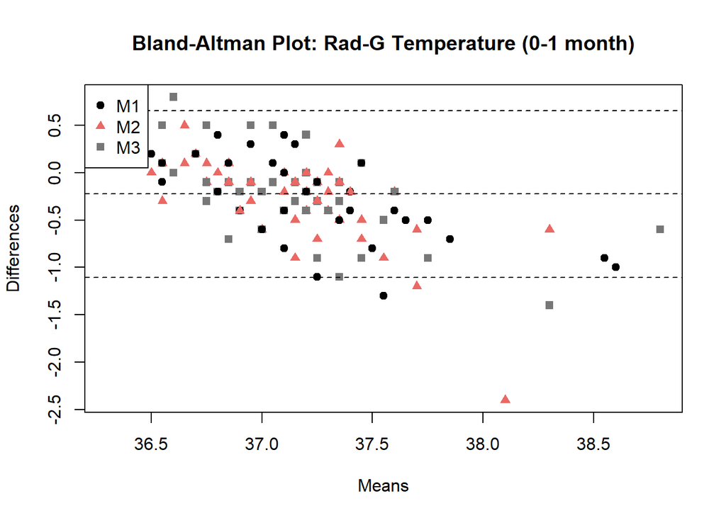

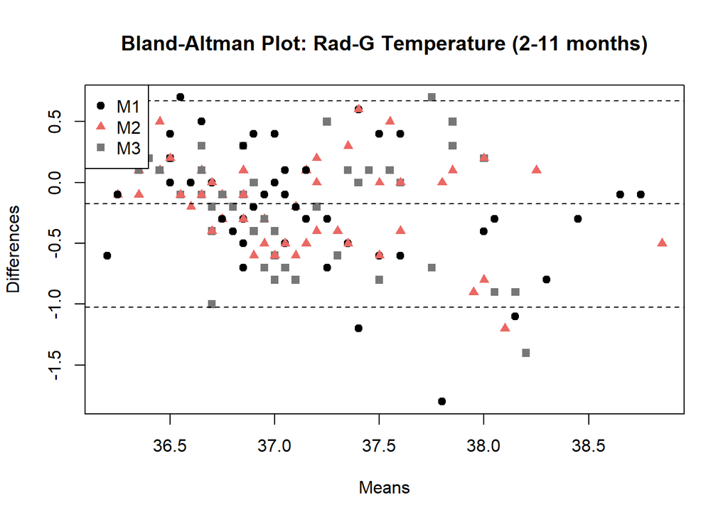

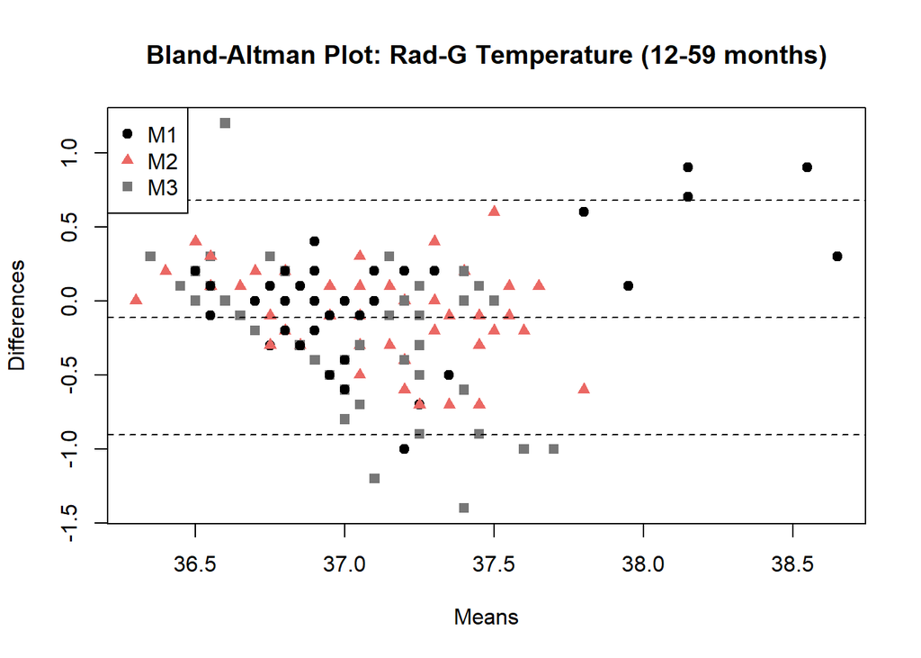

### Oxygen

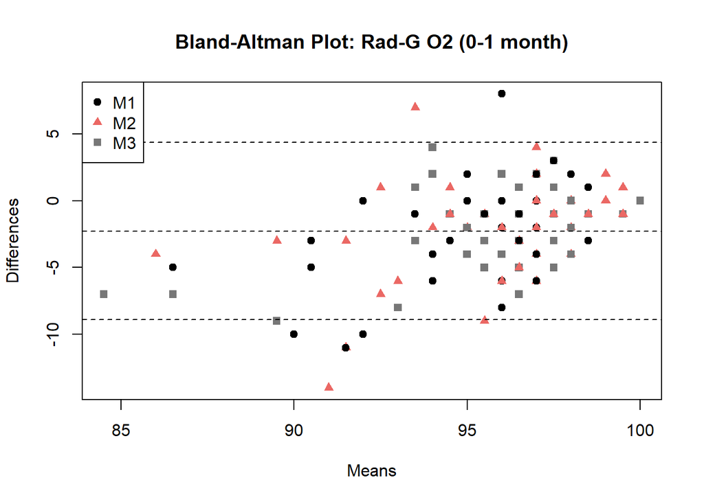

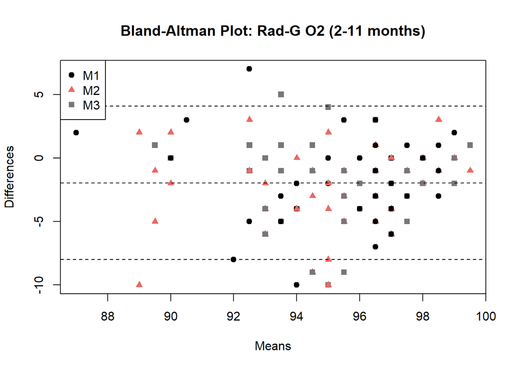

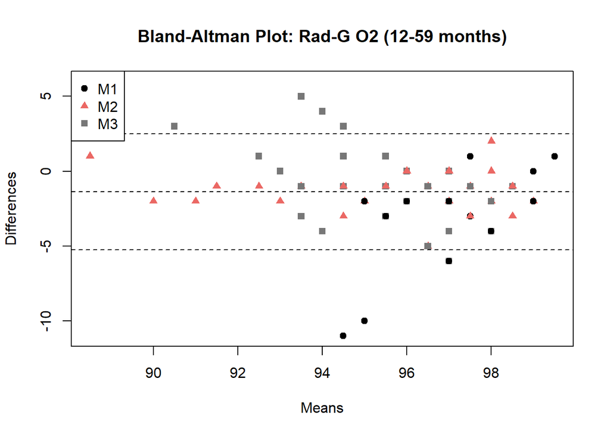

### Profusion Index

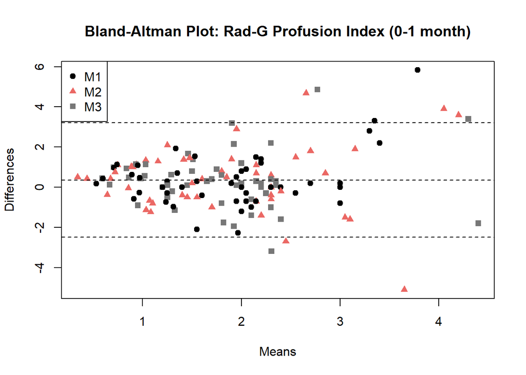

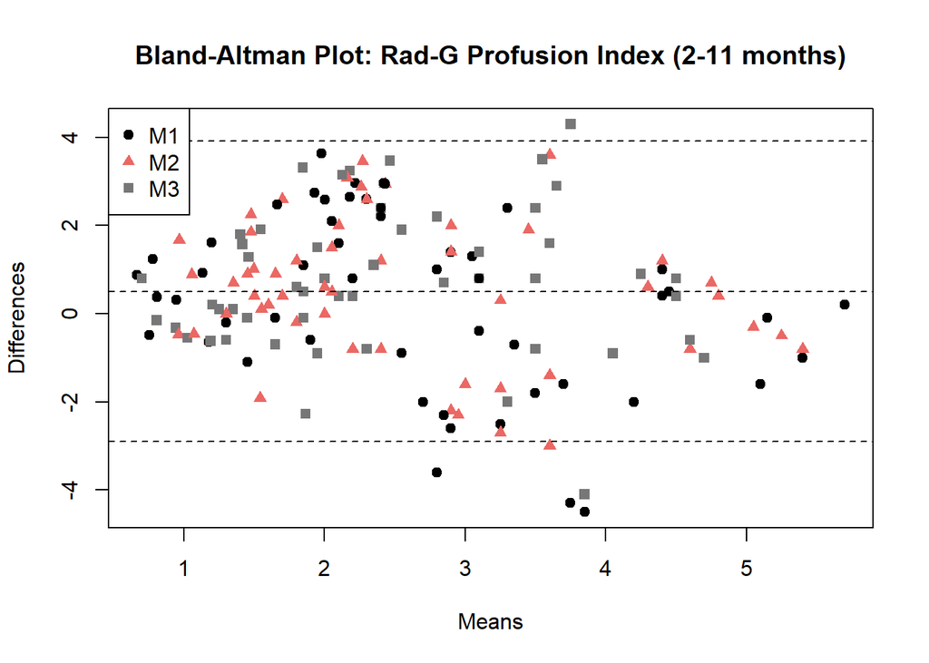

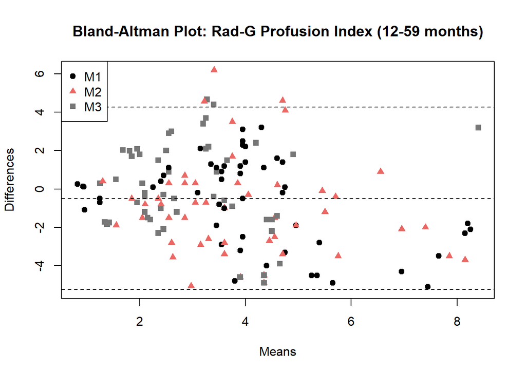